# Proyecto Final

| variable_fila | variable_columna | chi_cuadrado | gl | p_valor | v_cramer | decision |
| --- | --- | --- | --- | --- | --- | --- |
| Major_Category | Primary_Use_Case | 22141.285 | 16 | 0.000 | 0.333 | Asociacion |
| Year_of_Study | Burnout_Risk_Level | 1423.991 | 8 | 0.000 | 0.119 | Asociacion |
| Burnout_Risk_Level | Paid_Subscription | 593.768 | 2 | 0.000 | 0.109 | Asociacion |
| Major_Category | Prompt_Engineering_Skill | 565.275 | 8 | 0.000 | 0.075 | Asociacion |
| Major_Category | Burnout_Risk_Level | 376.269 | 8 | 0.000 | 0.061 | Asociacion |
| Institutional_Policy | Burnout_Risk_Level | 153.397 | 4 | 0.000 | 0.039 | Asociacion |
| Major_Category | Paid_Subscription | 110.857 | 4 | 0.000 | 0.047 | Asociacion |
| Primary_Use_Case | Prompt_Engineering_Skill | 118.336 | 8 | 0.000 | 0.034 | Asociacion |
| Primary_Use_Case | Burnout_Risk_Level | 80.476 | 8 | 0.000 | 0.028 | Asociacion |
| Primary_Use_Case | Paid_Subscription | 21.404 | 4 | 0.000 | 0.021 | Asociacion |
| Prompt_Engineering_Skill | Paid_Subscription | 11.862 | 2 | 0.003 | 0.015 | Asociacion |
| Major_Category | Institutional_Policy | 11.910 | 8 | 0.155 | 0.011 | Sin evidencia suficiente |
| Year_of_Study | Institutional_Policy | 11.508 | 8 | 0.175 | 0.011 | Sin evidencia suficiente |
| Major_Category | Year_of_Study | 20.653 | 16 | 0.192 | 0.010 | Sin evidencia suficiente |
| Prompt_Engineering_Skill | Burnout_Risk_Level | 5.466 | 4 | 0.243 | 0.007 | Sin evidencia suficiente |
| Year_of_Study | Paid_Subscription | 5.331 | 4 | 0.255 | 0.010 | Sin evidencia suficiente |
| Primary_Use_Case | Institutional_Policy | 8.694 | 8 | 0.369 | 0.009 | Sin evidencia suficiente |
| Year_of_Study | Prompt_Engineering_Skill | 6.263 | 8 | 0.618 | 0.008 | Sin evidencia suficiente |
| Year_of_Study | Primary_Use_Case | 13.533 | 16 | 0.633 | 0.008 | Sin evidencia suficiente |
| Institutional_Policy | Paid_Subscription | 0.892 | 2 | 0.640 | 0.004 | Sin evidencia suficiente |
| Prompt_Engineering_Skill | Institutional_Policy | 0.611 | 4 | 0.962 | 0.002 | Sin evidencia suficiente |

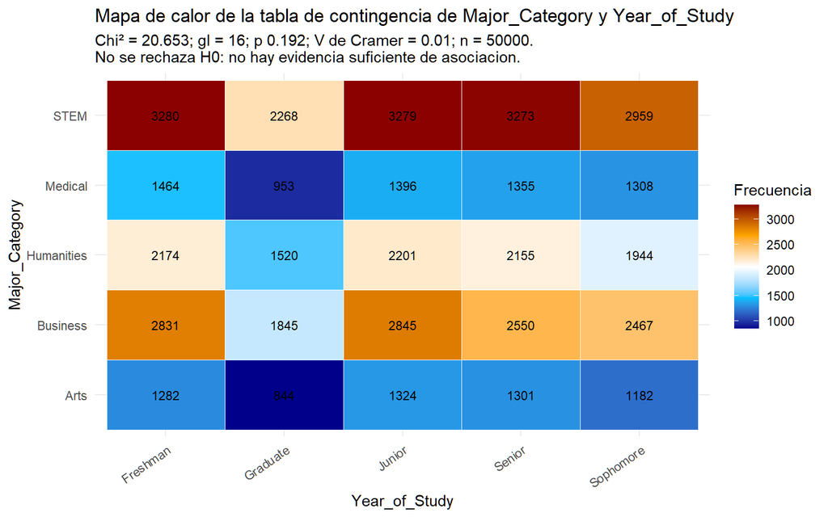

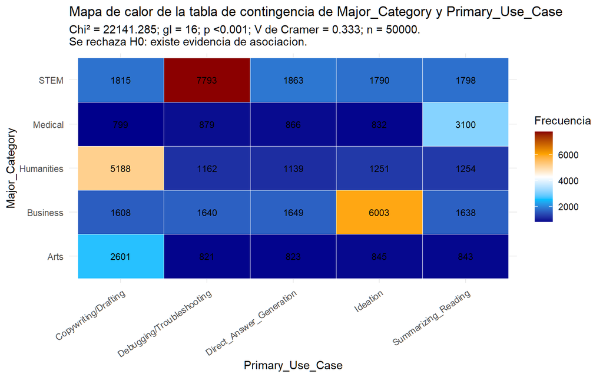

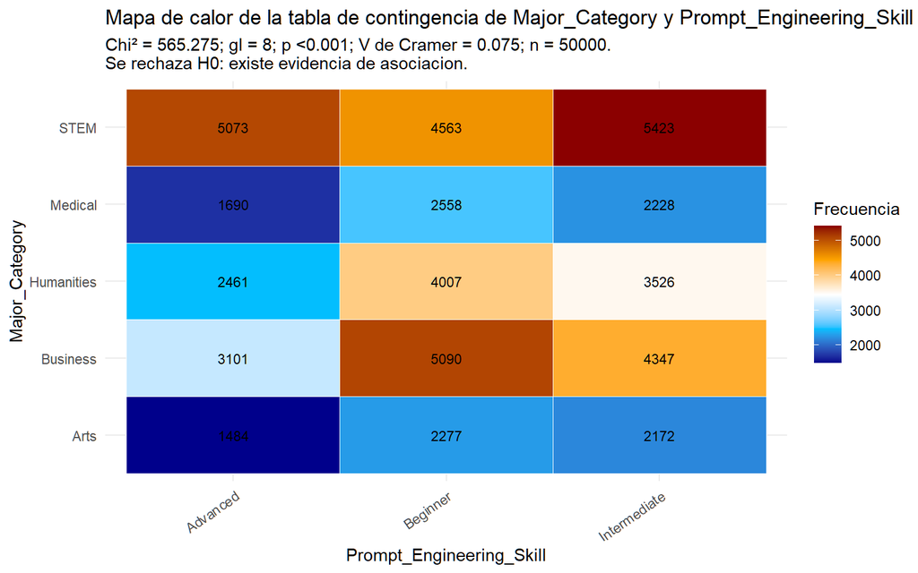

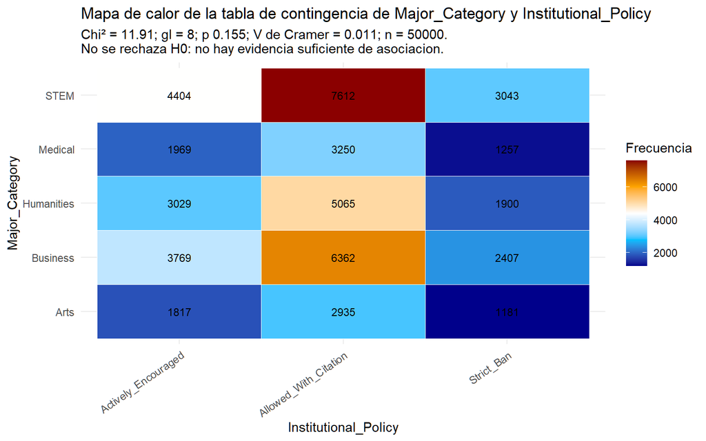

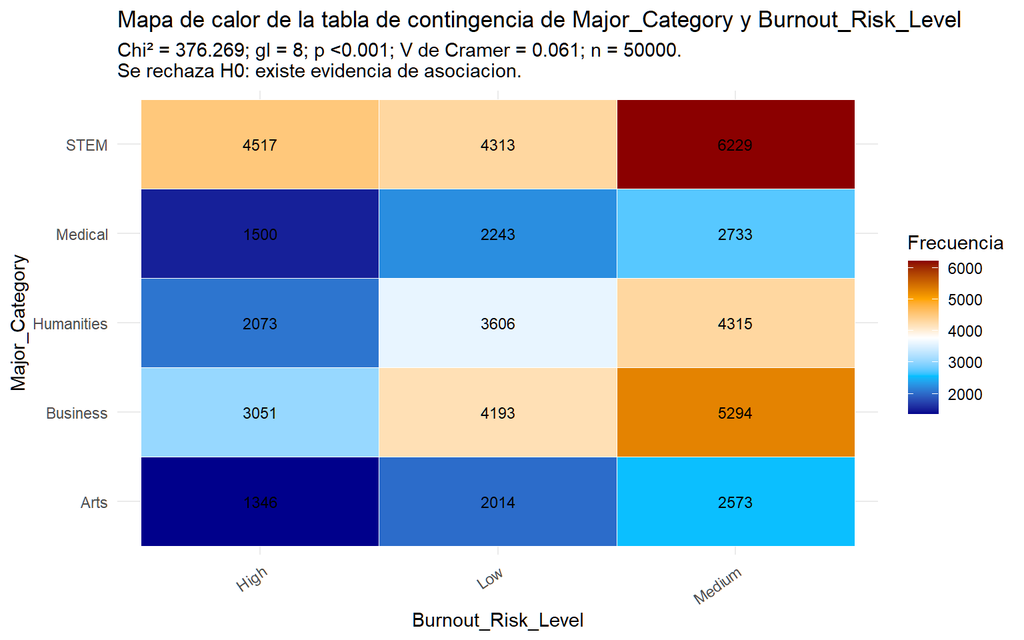

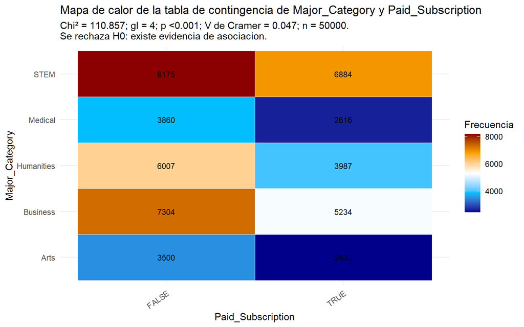

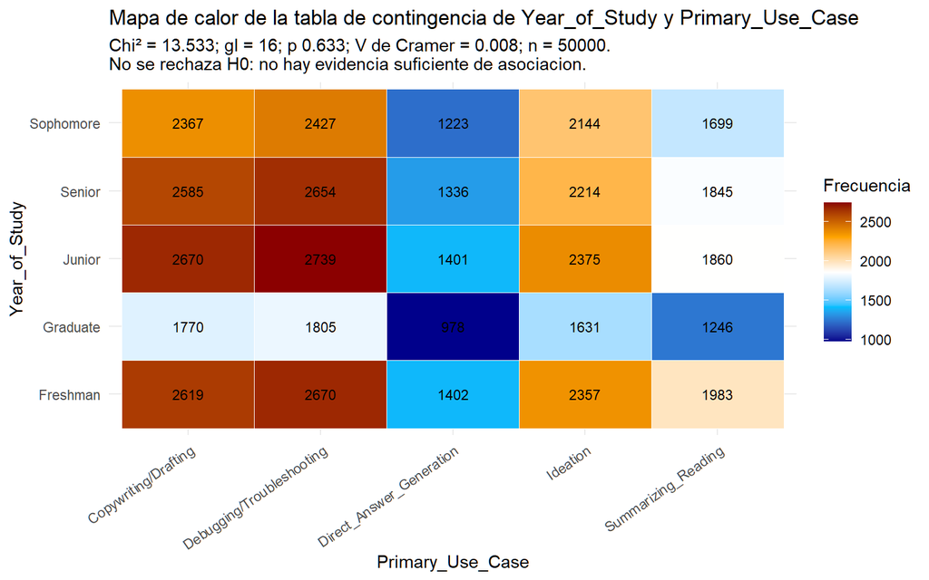

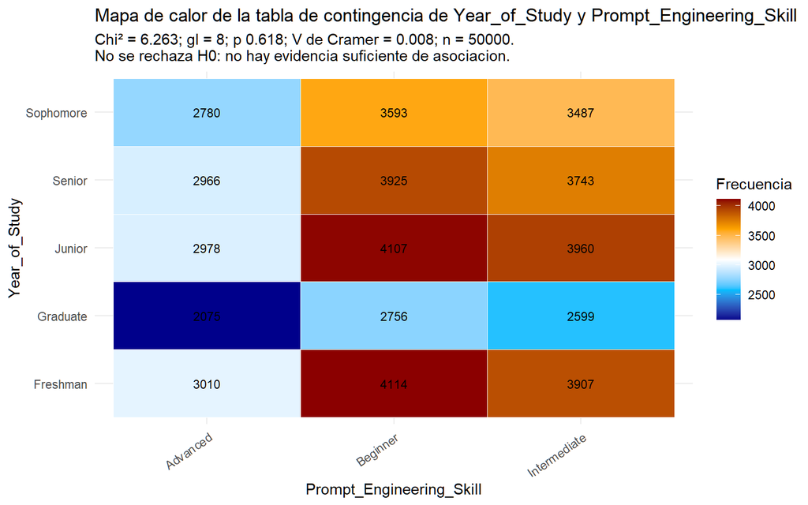

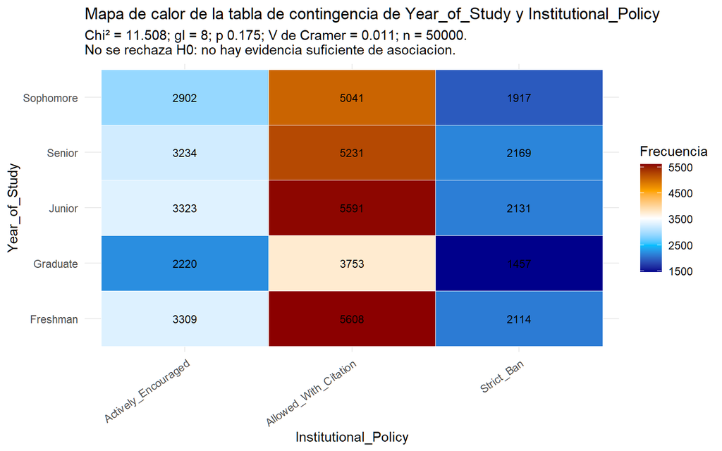

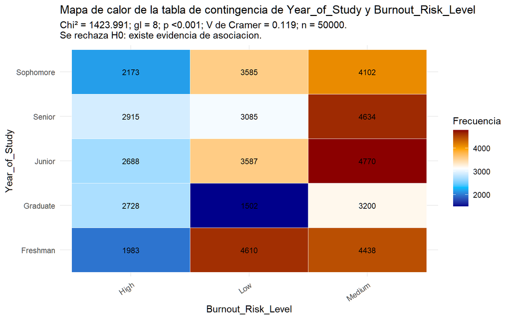

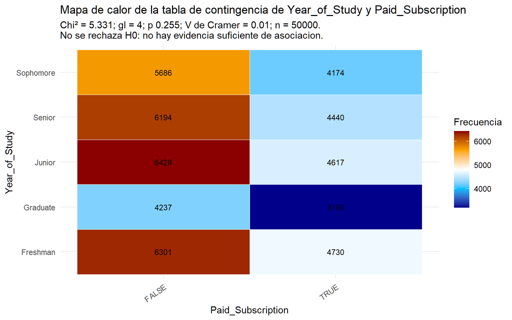

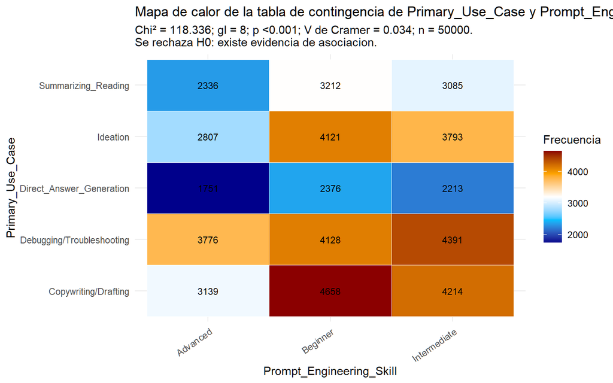

[9 more figures not shown]

```r
pares_cat <- combn(names(matriz_cat), 2, simplify = FALSE)

resultados_chi <- map_dfr(
  pares_cat,
  ~prueba_chi(matriz_cat, .x[1], .x[2])
) %>%
  arrange(p_valor, desc(v_cramer))

resumen_chi <- resultados_chi |>
  summarise(
    asociaciones_significativas = sum(p_valor < 0.05),
    v_maxima = max(v_cramer, na.rm = TRUE),
    fila_v_maxima = variable_fila[which.max(v_cramer)],
    columna_v_maxima = variable_columna[which.max(v_cramer)]
  )

kable_ajustada(resultados_chi)
```

Cruces con evidencia de asociación en el análisis (11 de 21 evaluados):

- `Major_Category` y `Primary_Use_Case`: $p$ < 0.001; $V$ de Cramer = 0.333.
- `Year_of_Study` y `Burnout_Risk_Level`: $p$ < 0.001; $V$ de Cramer = 0.119.
- `Burnout_Risk_Level` y `Paid_Subscription`: $p$ < 0.001; $V$ de Cramer = 0.109.
- `Major_Category` y `Prompt_Engineering_Skill`: $p$ < 0.001; $V$ de Cramer = 0.075.
- `Major_Category` y `Burnout_Risk_Level`: $p$ < 0.001; $V$ de Cramer = 0.061.
- `Institutional_Policy` y `Burnout_Risk_Level`: $p$ < 0.001; $V$ de Cramer = 0.039.
- `Major_Category` y `Paid_Subscription`: $p$ < 0.001; $V$ de Cramer = 0.047.
- `Primary_Use_Case` y `Prompt_Engineering_Skill`: $p$ < 0.001; $V$ de Cramer = 0.034.
- `Primary_Use_Case` y `Burnout_Risk_Level`: $p$ < 0.001; $V$ de Cramer = 0.028.
- `Primary_Use_Case` y `Paid_Subscription`: $p$ < 0.001; $V$ de Cramer = 0.021.
- `Prompt_Engineering_Skill` y `Paid_Subscription`: $p$ = 0.003; $V$ de Cramer = 0.015.

La asociación de mayor magnitud corresponde a Major_Category y Primary_Use_Case, con $V$ = 0.333 (moderada). Por tanto, aun cuando existan p-valores menores a 0.05, la relevancia sustantiva de cada cruce depende de su $V$ de Cramer. Con 50 000 casos, la significancia por sí sola no basta para describir una relación como importante.

En cada mapa de calor, una mayor intensidad representa una frecuencia absoluta mas alta. Esta lectura debe considerar los tamanos marginales de las categorias, ya que una celda puede ser alta por la frecuencia general de una categoria y no necesariamente por una asociacion especifica.

### Correlaciones

La matriz de correlaciones resume la direccion y la intensidad de las relaciones entre variables numericas u ordinales codificadas. Una correlacion no implica causalidad; describe como varian dos variables de manera conjunta.

Se utilizara del metodo de correlacion de Spearman para para el analisis general y la se utilizara la correlacion de Pearson solo en las variables cuantitativas continuas

#### Matriz de correlaciones mixta

```r
mix <- df |>
  select(-Primary_Use_Case,-Major_Category) |>
  mutate(across(where(is.factor), as.numeric),
         across(where(is.logical), as.numeric))

mix_corr <- mixedCor(
    data = mix,
    c = c("Pre_Semester_GPA", "Weekly_GenAI_Hours", "Traditional_Study_Hours",
          "Post_Semester_GPA", "Skill_Retention_Score", "Tool_Diversity",
          "Perceived_AI_Dependency", "Anxiety_Level_During_Exams"),
    p = c("Year_of_Study", "Prompt_Engineering_Skill", "Burnout_Risk_Level",
          "Institutional_Policy"),
    d = c("Paid_Subscription")
  )
```

```r
correlaciones(
  mix_corr$rho,
  cor_method = "Matriz Mixta",
  only_hm = TRUE)
```

[figure not shown]

La relación positiva más fuerte corresponde a `Pre_Semester_GPA` y `Post_Semester_GPA` ($r$ = 0.927, magnitud fuerte): los estudiantes con GPA inicial más alto tienden tambien a presentar GPA posterior mas alto. Esta asociacion no demuestra por si sola un aumento promedio del GPA ni una relacion causal.

`Prompt_Engineering_Skill` presenta una correlación fuerte de $r$ = 0.675 con `Tool_Diversity`. El patrón es compatible con que quienes declaran mayor habilidad utilicen más herramientas, pero también podría reflejar experiencia previa o autoevaluación compartida.

`Burnout_Risk_Level` presenta correlaciones fuerte y moderada de $r$ = 0.523 con `Weekly_GenAI_Hours` y $r$ = 0.411 con `Perceived_AI_Dependency`. La dirección de estas asociaciones indica que valores mayores tienden a observarse conjuntamente, pero no demuestra que el uso de IA cause $Burnout$. Además, se observan correlaciones ligeras de la variable `Institutional_Policy` con `Burnout_Risk_Level` y `Anxiety_Level_During_Exams`, aunque no se puede determinar causalidad solo con estos valores.

`Weekly_GenAI_Hours` presenta asociaciones de $r$ = -0.118 con `Skill_Retention_Score` y $r$ = -0.157 con `Traditional_Study_Hours`, ambas de magnitud débil. En cambio, su relación con dependencia percibida es $r$ = 0.665 (fuerte), y con ansiedad es $r$ = 0.269 (débil). El conjunto podría indicar que el volumen de uso de IA está más ligado a dependencia y ansiedad que a mejoras en retención; también es posible que estudiantes con mayor dependencia o presión académica recurran más a estas herramientas. Los datos transversales no permiten decidir entre esas explicaciones.

## Modelos aplicados

### Marco metodológico del modelado

Este documento combina análisis descriptivo y técnicas de aprendizaje no supervisado, por lo que conviene distinguir los niveles empleados:

- **Paradigma:** aprendizaje no supervisado, porque no se proporciona una variable objetivo que el algoritmo deba predecir.
- **Técnicas:** análisis factorial para estudiar relaciones entre variables y análisis de conglomerados para agrupar estudiantes.
- **Algoritmos o estimadores:** ejes principales y WLSMV para el análisis factorial, y k-prototypes para segmentar datos de naturaleza mixta.
- **Modelo ajustado:** el resultado concreto obtenido al aplicar cada algoritmo a estos datos.
- **Proceso de modelado:** preparación, exploración y confirmación factorial, diagnóstico del número de conglomerados, ajuste sobre una submuestra e interpretación descriptiva.

A partir de esta sección se crea una partición para separar exploración y confirmación factorial. El análisis de conglomerados utiliza una única submuestra reproducible para diagnóstico y selección descriptiva.

El análisis factorial separa desarrollo y confirmación para evitar confirmar la estructura en los mismos datos. El agrupamiento no estima capacidad predictiva: describe perfiles retrospectivos y finalmente reajusta la solución sobre el conjunto completo.

### Análisis multivariado

En esta etapa se estudian conjuntamente múltiples variables. El análisis factorial resume relaciones entre variables observadas; no agrupa individuos. Posteriormente, k-prototypes utiliza las características seleccionadas para formar grupos de estudiantes.

### Partición para análisis factorial

La estructura factorial se explora con una mitad de los registros y se evalúa con la otra mitad. Esta separación evita confirmar en los mismos datos una estructura descubierta durante el AFE.

| particion | registros |
| --- | --- |
| Desarrollo AFE | 25000 |
| Confirmación AFC | 25000 |

### Análisis factorial exploratorio

### Aplicando el metodo de factorizacion por ejes principales

El AFE estudia si varias variables observadas comparten dimensiones comunes. Las variables ordinales se conservan como factores ordenados y se utiliza una matriz de correlaciones mixta. Los tres intentos originales se mantienen para documentar el proceso de depuración, pero todos se estiman exclusivamente con la muestra de desarrollo. Las escalas de diez categorías se aproximan como continuas únicamente en el AFE debido al límite operativo de `psych::mixedCor`; en el AFC se declaran explícitamente como ordinales.

### Intento AFE 1: conjunto amplio

|  | Year_of_Study | Pre_Semester_GPA | Weekly_GenAI_Hours | Prompt_Engineering_Skill | Tool_Diversity | Paid_Subscription | Traditional_Study_Hours | Perceived_AI_Dependency | Institutional_Policy | Anxiety_Level_During_Exams | Post_Semester_GPA | Skill_Retention_Score | Burnout_Risk_Level |
| --- | --- | --- | --- | --- | --- | --- | --- | --- | --- | --- | --- | --- | --- |
| 102986 | 1 | 3.059 | 27.56 | 1 | 3 | 1 | 8.36 | 3 | 2 | 7 | 3.246 | 53.25 | 2 |
| 129925 | 1 | 3.024 | 14.52 | 1 | 3 | 1 | 11.83 | 4 | 1 | 6 | 3.158 | 65.24 | 2 |
| 129710 | 4 | 3.673 | 15.88 | 1 | 1 | 1 | 17.12 | 8 | 2 | 6 | 4.000 | 99.74 | 2 |
| 137529 | 2 | 3.621 | 1.15 | 3 | 3 | 0 | 8.85 | 3 | 1 | 4 | 3.760 | 73.86 | 1 |
| 102757 | 2 | 3.314 | 0.33 | 1 | 3 | 1 | 13.14 | 1 | 1 | 4 | 3.505 | 79.65 | 1 |
| 145404 | 5 | 2.425 | 27.99 | 1 | 3 | 1 | 7.60 | 8 | 2 | 8 | 2.818 | 70.76 | 3 |

```
## Kaiser-Meyer-Olkin factor adequacy
## Call: KMO(r = matrix_AF1)
## Overall MSA =  0.54
## MSA for each item =
##              Year_of_Study           Pre_Semester_GPA
##                       0.24                       0.45
##         Weekly_GenAI_Hours   Prompt_Engineering_Skill
##                       0.65                       0.51
##             Tool_Diversity          Paid_Subscription
##                       0.53                       0.78
##    Traditional_Study_Hours    Perceived_AI_Dependency
##                       0.24                       0.69
##       Institutional_Policy Anxiety_Level_During_Exams
##                       0.43                       0.80
##          Post_Semester_GPA      Skill_Retention_Score
##                       0.46                       0.66
##         Burnout_Risk_Level
##                       0.74
```

```
## $chisq
## [1] 105867.3
##
## $p.value
## [1] 0
##
## $df
## [1] 78
```

[figure not shown]

```
##
## Loadings:
##                            PA2    PA6    PA5    PA3    PA1    PA4
## Year_of_Study                                           0.603
## Pre_Semester_GPA            1.016
## Weekly_GenAI_Hours                 0.954
## Prompt_Engineering_Skill                  1.085
## Tool_Diversity                            0.620
## Paid_Subscription
## Traditional_Study_Hours                                        0.514
## Perceived_AI_Dependency            0.657
## Institutional_Policy
## Anxiety_Level_During_Exams                       0.655
## Post_Semester_GPA           0.928
## Skill_Retention_Score                     0.312
## Burnout_Risk_Level                 0.458                0.344
##
##                  PA2   PA6   PA5   PA3   PA1   PA4
## SS loadings    1.910 1.646 1.660 0.511 0.510 0.374
## Proportion Var 0.147 0.127 0.128 0.039 0.039 0.029
## Cumulative Var 0.147 0.274 0.401 0.441 0.480 0.509
```

### Intento AFE 2: exclusión de variables con baja adecuación

|  | Weekly_GenAI_Hours | Prompt_Engineering_Skill | Tool_Diversity | Paid_Subscription | Perceived_AI_Dependency | Anxiety_Level_During_Exams | Burnout_Risk_Level |
| --- | --- | --- | --- | --- | --- | --- | --- |
| 102986 | 27.56 | 1 | 3 | 1 | 3 | 7 | 2 |
| 129925 | 14.52 | 1 | 3 | 1 | 4 | 6 | 2 |
| 129710 | 15.88 | 1 | 1 | 1 | 8 | 6 | 2 |
| 137529 | 1.15 | 3 | 3 | 0 | 3 | 4 | 1 |
| 102757 | 0.33 | 1 | 3 | 1 | 1 | 4 | 1 |
| 145404 | 27.99 | 1 | 3 | 1 | 8 | 8 | 3 |

```
## Kaiser-Meyer-Olkin factor adequacy
## Call: KMO(r = matrix_AF2)
## Overall MSA =  0.63
## MSA for each item =
##         Weekly_GenAI_Hours   Prompt_Engineering_Skill
##                       0.65                       0.50
##             Tool_Diversity          Paid_Subscription
##                       0.50                       0.79
##    Perceived_AI_Dependency Anxiety_Level_During_Exams
##                       0.68                       0.85
##         Burnout_Risk_Level
##                       0.78
```

```
## $chisq
## [1] 41980.94
##
## $p.value
## [1] 0
##
## $df
## [1] 21
```

[figure not shown]

```
##
## Loadings:
##                            PA1    PA2
## Weekly_GenAI_Hours          0.889
## Prompt_Engineering_Skill           0.822
## Tool_Diversity                     0.820
## Paid_Subscription
## Perceived_AI_Dependency     0.746
## Anxiety_Level_During_Exams  0.333
## Burnout_Risk_Level          0.568
##
##                  PA1   PA2
## SS loadings    1.849 1.347
## Proportion Var 0.264 0.192
## Cumulative Var 0.264 0.457
```

### Intento AFE 3: conjunto depurado

|  | Weekly_GenAI_Hours | Prompt_Engineering_Skill | Tool_Diversity | Perceived_AI_Dependency | Anxiety_Level_During_Exams | Burnout_Risk_Level |
| --- | --- | --- | --- | --- | --- | --- |
| 102986 | 27.56 | 1 | 3 | 3 | 7 | 2 |
| 129925 | 14.52 | 1 | 3 | 4 | 6 | 2 |
| 129710 | 15.88 | 1 | 1 | 8 | 6 | 2 |
| 137529 | 1.15 | 3 | 3 | 3 | 4 | 1 |
| 102757 | 0.33 | 1 | 3 | 1 | 4 | 1 |
| 145404 | 27.99 | 1 | 3 | 8 | 8 | 3 |

```
## Kaiser-Meyer-Olkin factor adequacy
## Call: KMO(r = matrix_AF3)
## Overall MSA =  0.62
## MSA for each item =
##         Weekly_GenAI_Hours   Prompt_Engineering_Skill
##                       0.64                       0.50
##             Tool_Diversity    Perceived_AI_Dependency
##                       0.50                       0.67
## Anxiety_Level_During_Exams         Burnout_Risk_Level
##                       0.84                       0.77
```

```
## $chisq
## [1] 40212.4
##
## $p.value
## [1] 0
##
## $df
## [1] 15
```

[figure not shown]

```
##
## Loadings:
##                            PA2    PA1
## Weekly_GenAI_Hours          0.872
## Prompt_Engineering_Skill           0.821
## Tool_Diversity                     0.821
## Perceived_AI_Dependency     0.760
## Anxiety_Level_During_Exams  0.334
## Burnout_Risk_Level          0.569
##
##                  PA2   PA1
## SS loadings    1.774 1.347
## Proportion Var 0.296 0.224
## Cumulative Var 0.296 0.520
```

Los intentos anteriores permiten conservar la trazabilidad del análisis. Las soluciones con falta de convergencia, casos Heywood o factores definidos por un único indicador no deben interpretarse como estructuras confirmadas.

## Resultados

### Análisis factorial exploratorio final

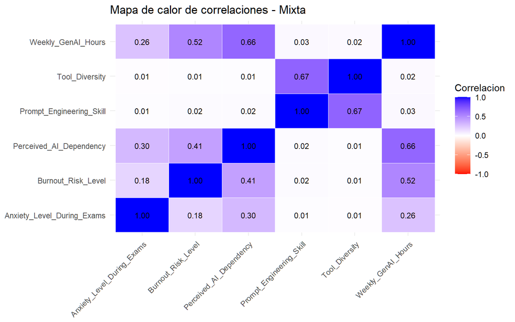

```
## Kaiser-Meyer-Olkin factor adequacy
## Call: KMO(r = matrix_afe_final)
## Overall MSA =  0.62
## MSA for each item =
##         Weekly_GenAI_Hours    Perceived_AI_Dependency
##                       0.64                       0.67
##         Burnout_Risk_Level Anxiety_Level_During_Exams
##                       0.77                       0.84
##   Prompt_Engineering_Skill             Tool_Diversity
##                       0.50                       0.50
```

```
## $chisq
## [1] 40212.4
##
## $p.value
## [1] 0
##
## $df
## [1] 15
```

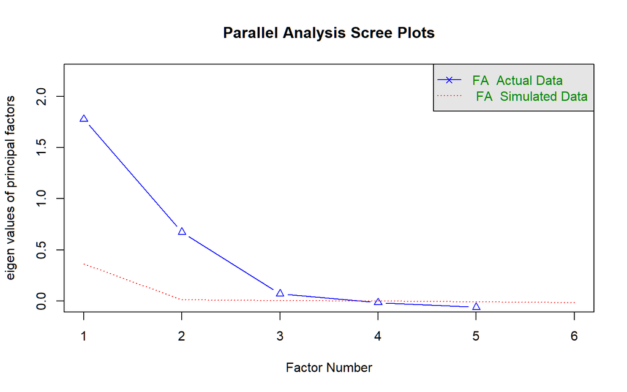

```
## Parallel analysis suggests that the number of factors =  3  and the number of components =  NA
```

```
##
## Loadings:
##                            PA1    PA2
## Weekly_GenAI_Hours          0.872
## Perceived_AI_Dependency     0.760
## Burnout_Risk_Level          0.569
## Anxiety_Level_During_Exams  0.334
## Prompt_Engineering_Skill           0.821
## Tool_Diversity                     0.821
##
##                  PA1   PA2
## SS loadings    1.774 1.347
## Proportion Var 0.296 0.224
## Cumulative Var 0.296 0.520
```

El KMO de 0.619 indica una adecuación limitada pero utilizable para buscar factores comunes. Bartlett rechaza una matriz identidad, lo que confirma que existen correlaciones aprovechables, aunque con una muestra grande no informa por sí solo sobre su intensidad. Las comunalidades se sitúan entre 0.112 y 0.761; por ello la representación de cada indicador debe juzgarse junto con sus cargas y no solo con la varianza total. Los indicadores con carga principal absoluta inferior a 0.40 son Anxiety_Level_During_Exams ; su interpretación factorial requiere especial cautela.

### Análisis factorial confirmatorio

El AFC comprueba en la muestra reservada una estructura de dos factores y seis indicadores. Dependencia percibida, ansiedad, burnout y habilidad de *prompt engineering* se tratan como ordinales; por ello se utiliza el estimador WLSMV. Este es un modelo de medición, no un modelo predictivo.

### Preparación y especificación

```r
modelo_confirmatorio_ia <- '
  Estudio_AI_dominante =~ Weekly_GenAI_Hours +
    Perceived_AI_Dependency + Anxiety_Level_During_Exams +
    Burnout_Risk_Level

  Habilidad_Tecnica =~ a*Tool_Diversity + a*Prompt_Engineering_Skill
'


df_AFC_confirmacion <- preparar_afc(df_confirmacion_afc) |>
  a_numerico_ordinal()
```

### Ajuste independiente del AFC

```r
fit_afc_confirmacion <- cfa(
  model = modelo_confirmatorio_ia,
  data = df_AFC_confirmacion,
  ordered = c(
    "Perceived_AI_Dependency",
    "Burnout_Risk_Level",
    "Anxiety_Level_During_Exams",
    "Prompt_Engineering_Skill"
  ),
  estimator = "WLSMV",
  std.lv = TRUE
)

summary(fit_afc_confirmacion, fit.measures = TRUE, standardized = TRUE)
```

```
## lavaan 0.6-21 ended normally after 19 iterations
##
##   Estimator                                       DWLS
##   Optimization method                           NLMINB
##   Number of model parameters                        33
##   Number of equality constraints                     1
##
##   Number of observations                         25000
##
## Model Test User Model:
##                                               Standard      Scaled
##   Test Statistic                               183.367     253.145
##   Degrees of freedom                                 9           9
##   P-value (Unknown)                                 NA       0.000
##   Scaling correction factor                                  0.728
##   Shift parameter                                            1.343
##     simple second-order correction
##
## Model Test Baseline Model:
##
##   Test statistic                             36945.773   27897.394
##   Degrees of freedom                                15          15
##   P-value                                           NA       0.000
##   Scaling correction factor                                  1.325
##
## User Model versus Baseline Model:
##
##   Comparative Fit Index (CFI)                    0.995       0.991
##   Tucker-Lewis Index (TLI)                       0.992       0.985
##
##   Robust Comparative Fit Index (CFI)                            NA
##   Robust Tucker-Lewis Index (TLI)                               NA
##
## Root Mean Square Error of Approximation:
##
##   RMSEA                                          0.028       0.033
##   90 Percent confidence interval - lower         0.024       0.030
##   90 Percent confidence interval - upper         0.031       0.037
##   P-value H_0: RMSEA <= 0.050                    1.000       1.000
##   P-value H_0: RMSEA >= 0.080                    0.000       0.000
```

[output cut: 59 more lines]

```
##     Brnt_Rsk_Lvl|1   -0.456    0.008  -55.368    0.000   -0.456   -0.456
##     Brnt_Rsk_Lvl|2    0.669    0.009   77.693    0.000    0.669    0.669
##     Prmpt_Engn_S|1   -0.329    0.008  -40.731    0.000   -0.329   -0.329
##     Prmpt_Engn_S|2    0.600    0.008   70.885    0.000    0.600    0.600
##
## Variances:
##                    Estimate  Std.Err  z-value  P(>|z|)   Std.lv  Std.all
##    .Wekly_GnAI_Hrs   16.747    0.582   28.770    0.000   16.747    0.244
##    .Prcvd_AI_Dpndn    0.440                               0.440    0.440
##    .Anxty_Lvl_Dr_E    0.873                               0.873    0.873
##    .Burnot_Rsk_Lvl    0.660                               0.660    0.660
##    .Tool_Diversity    0.655    0.010   62.987    0.000    0.655    0.462
##    .Prmpt_Engnrn_S    0.237                               0.237    0.237
##     Estud_AI_dmnnt    1.000                               1.000    1.000
##     Habilidad_Tcnc    1.000                               1.000    1.000
```

```r
indices_ajuste_afc <- fitMeasures(
  fit_afc_confirmacion,
  c("chisq.scaled", "df.scaled", "pvalue.scaled",
    "cfi.scaled", "tli.scaled", "rmsea.scaled",
    "nfi", "gfi")
)


kable_ajustada(indices_ajuste_afc, ajustar_ancho = FALSE)
```

|  | x |
| --- | --- |
| chisq.scaled | 253.14457136 |
| df.scaled | 9.00000000 |
| pvalue.scaled | 0.00000000 |
| cfi.scaled | 0.99124377 |
| tli.scaled | 0.98540629 |
| rmsea.scaled | 0.03294132 |
| nfi | 0.99503686 |
| gfi | 0.99951110 |

### Diagrama de trayectorias del modelo 1

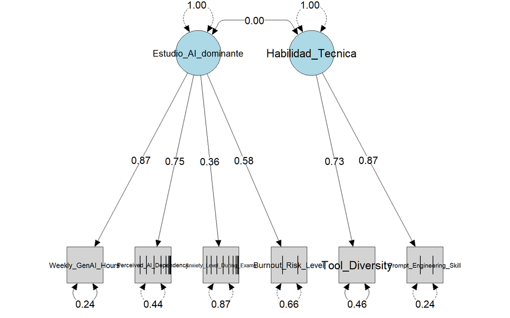

El Análisis Factorial Confirmatorio produjo $\chi^2$(9) = 253.145 y $p$ < 0.001. La prueba aporta evidencia de diferencias entre las matrices observada y estimada; por el tamaño muestral debe interpretarse junto con los índices aproximados. Los índices de ajuste fueron $CFI$ = 0.991, $TLI$ = 0.985, $RMSEA$ = 0.033, $NFI$ = 0.995 y $GFI$ = 1. En conjunto, estos valores son compatibles con un ajuste aproximado favorable. La conclusión se basa en el patrón conjunto de índices: valores incrementales altos y RMSEA bajo apoyarían la especificación, mientras que desacuerdos entre ellos señalarían ajuste parcial. Estos umbrales son referencias prácticas, no pruebas absolutas de que la estructura sea la única explicación posible.

### Reajuste descriptivo y creación de características

Después de evaluar la especificación en confirmación, se reajusta el mismo modelo sobre toda la muestra exclusivamente para producir características descriptivas. Los índices reportados arriba siguen siendo los de la muestra reservada.

```r
df_AFC_total <- preparar_afc(df) |>  a_numerico_ordinal()

fit_afc_total <- cfa(
  model = modelo_confirmatorio_ia,
  data = df_AFC_total,
  ordered = c(
    "Perceived_AI_Dependency",
    "Burnout_Risk_Level",
    "Anxiety_Level_During_Exams",
    "Prompt_Engineering_Skill"
  ),
  estimator = "WLSMV",
  std.lv = TRUE
)

puntajes_factores <- lavPredict(fit_afc_total)

puntajes_factores <- as.data.frame(puntajes_factores)

df_final_con_factores <- df |>
  mutate(
    AI_Dominated_Study_Factor = puntajes_factores$Estudio_AI_dominante,
    Technical_Skill_Factor = puntajes_factores$Habilidad_Tecnica)

stopifnot(
  nrow(df_final_con_factores) == 50000,
  !anyNA(df_final_con_factores)
)

head(df_final_con_factores)
```

|  | Major_Category | Year_of_Study | Pre_Semester_GPA | Weekly_GenAI_Hours | Primary_Use_Case | Prompt_Engineering_Skill | Tool_Diversity | Paid_Subscription | Traditional_Study_Hours | Perceived_AI_Dependency | Institutional_Policy | Anxiety_Level_During_Exams | Post_Semester_GPA | Skill_Retention_Score | Burnout_Risk_Level | AI_Dominated_Study_Factor | Technical_Skill_Factor |
| --- | --- | --- | --- | --- | --- | --- | --- | --- | --- | --- | --- | --- | --- | --- | --- | --- | --- |
| 100001 | Humanities | Senior | 2.418 | 23.31 | Copywriting/Drafting | Beginner | 1 | TRUE | 8.13 | 5 | Allowed_With_Citation | 6 | 2.393 | 86.44 | High | 1.5707443 | -1.2159458 |
| 100002 | Medical | Junior | 3.821 | 1.12 | Ideation | Advanced | 5 | FALSE | 16.65 | 3 | Allowed_With_Citation | 9 | 3.696 | 69.39 | Low | -0.5996190 | 1.4823703 |
| 100003 | Business | Freshman | 3.398 | 21.26 | Summarizing_Reading | Beginner | 2 | FALSE | 10.35 | 5 | Strict_Ban | 9 | 3.499 | 73.93 | Medium | 1.3233325 | -0.8030425 |
| 100004 | Business | Senior | 3.789 | 1.82 | Copywriting/Drafting | Intermediate | 4 | FALSE | 15.23 | 2 | Allowed_With_Citation | 2 | 4.000 | 63.58 | Medium | -0.7386654 | 0.4314733 |
| 100005 | STEM | Sophomore | 3.635 | 9.29 | Debugging/Troubleshooting | Advanced | 4 | FALSE | 12.55 | 4 | Allowed_With_Citation | 4 | 3.798 | 100.00 | Medium | 0.1720548 | 1.0783684 |
| 100006 | STEM | Junior | 3.449 | 6.50 | Debugging/Troubleshooting | Beginner | 1 | FALSE | 14.19 | 4 | Allowed_With_Citation | 5 | 3.666 | 65.92 | High | 0.1490391 | -1.2245485 |

### Análisis de conglomerados mediante k-prototypes

Esta segmentación es **retrospectiva**, porque incluye resultados posteriores al semestre como GPA final, retención y burnout. En consecuencia, sus grupos describen perfiles al final del periodo y no pueden utilizarse para predecir esas mismas variables.

Se utiliza k-prototypes con distancia de Gower para combinar variables continuas, discretas, nominales, ordinales y dicotómicas. En el conjunto con factores se excluyen los seis indicadores empleados por el AFC, pues su información se resume mediante los dos puntajes factoriales; las demás variables categóricas se conservan para aportar información no representada por esos factores latentes. El conjunto sin factores mantiene los indicadores originales y excluye únicamente los puntajes factoriales.

### Preparación de los 2 conjuntos

```r
df_kproto_conjunto1 <- df_final_con_factores |>
  select( -Weekly_GenAI_Hours,-Perceived_AI_Dependency,
          -Burnout_Risk_Level, -Anxiety_Level_During_Exams,
          -Prompt_Engineering_Skill, -Tool_Diversity,
         -Major_Category, -Year_of_Study) |>
  preparar_tipos_kproto()



df_kproto_conjunto2 <- df_final_con_factores |>
  select(-Technical_Skill_Factor, -AI_Dominated_Study_Factor,
         -Major_Category, -Year_of_Study) |>
  preparar_tipos_kproto()

conjuntos_kproto <- list(
  complementarias_con_factores = df_kproto_conjunto1,
  originales_sin_factor = df_kproto_conjunto2
)


stopifnot(all(vapply(conjuntos_kproto, nrow, integer(1)) == nrow(df)))
```

### Selección de la submuestra

| conjunto | registros |
| --- | --- |
| Dataset completo | 50000 |
| Submuestra para k-prototypes | 15000 |

### Diagnóstico del número de conglomerados

Los gráficos siguientes comparan las soluciones de dos a ocho conglomerados ajustadas sobre la submuestra reproducible de 15 000 casos. La silueta se estima sobre los mismos 2 000 estudiantes en todos los valores de $k$ y en ambos conjuntos, evitando construir la matriz de distancias completa. En el gráfico de codo se buscan reducciones relevantes de la variación intragrupo; en el de silueta se prefieren valores promedio más altos.

[figure not shown]

La distancia total intragrupo disminuyó de manera coherente al aumentar k en ambos conjuntos. La mayor silueta diagnóstica del conjunto con factores se obtuvo con $k = 8$ (0.255), mientras que para el conjunto sin factores se obtuvo con $k = 2$ (0.158). Los modelos se ajustaron sobre la misma submuestra de 15 000 observaciones utilizada por la tabla posterior. Para hacer viable el cálculo, la silueta se estimó sobre una muestra fija común de 2 000 estudiantes.

### Ajuste y selección sobre la submuestra

| clave | conjunto | k | distancia_total_intragrupo | silueta_submuestra | proporcion_minima | elegible |
| --- | --- | --- | --- | --- | --- | --- |
| complementarias_con_factores__k8 | complementarias_con_factores | 8 | 20476.42 | 0.255 | 0.072 | TRUE |
| complementarias_con_factores__k7 | complementarias_con_factores | 7 | 20893.34 | 0.233 | 0.123 | TRUE |
| complementarias_con_factores__k2 | complementarias_con_factores | 2 | 29238.76 | 0.197 | 0.456 | TRUE |
| complementarias_con_factores__k6 | complementarias_con_factores | 6 | 22207.44 | 0.196 | 0.145 | TRUE |
| originales_sin_factor__k2 | originales_sin_factor | 2 | 43620.66 | 0.158 | 0.432 | TRUE |
| complementarias_con_factores__k5 | complementarias_con_factores | 5 | 23579.74 | 0.144 | 0.174 | TRUE |
| complementarias_con_factores__k3 | complementarias_con_factores | 3 | 27099.20 | 0.133 | 0.304 | TRUE |
| complementarias_con_factores__k4 | complementarias_con_factores | 4 | 25240.58 | 0.118 | 0.202 | TRUE |
| originales_sin_factor__k3 | originales_sin_factor | 3 | 40706.67 | 0.117 | 0.288 | TRUE |
| originales_sin_factor__k7 | originales_sin_factor | 7 | 35924.08 | 0.096 | 0.106 | TRUE |
| originales_sin_factor__k4 | originales_sin_factor | 4 | 39209.79 | 0.092 | 0.190 | TRUE |
| originales_sin_factor__k5 | originales_sin_factor | 5 | 37778.67 | 0.091 | 0.120 | TRUE |
| originales_sin_factor__k8 | originales_sin_factor | 8 | 35187.26 | 0.090 | 0.069 | TRUE |
| originales_sin_factor__k6 | originales_sin_factor | 6 | 36717.56 | 0.089 | 0.113 | TRUE |

#### Modelo elegido

| clave | conjunto | k | distancia_total_intragrupo | silueta_submuestra | proporcion_minima | elegible |
| --- | --- | --- | --- | --- | --- | --- |
| complementarias_con_factores__k6 | complementarias_con_factores | 6 | 22207.44 | 0.196 | 0.145 | TRUE |

La solución elegida sobre la submuestra corresponde al conjunto complementarias_con_factores, con $k = 6$, silueta promedio 0.196 y un grupo mínimo equivalente al 14.5 % de la submuestra. La distancia total intragrupo se informa dentro de cada preparación, pero no se compara directamente entre conjuntos con distinta dimensionalidad.

### Evaluación descriptiva sobre la submuestra

| Grupo | Freq | Proporcion |
| --- | --- | --- |
| 1 | 2279 | 0.152 |
| 2 | 2881 | 0.192 |
| 3 | 2173 | 0.145 |
| 4 | 2429 | 0.162 |
| 5 | 2454 | 0.164 |
| 6 | 2784 | 0.186 |

| Grupo | Pre_Semester_GPA | Primary_Use_Case | Paid_Subscription | Traditional_Study_Hours | Institutional_Policy | Post_Semester_GPA | Skill_Retention_Score | AI_Dominated_Study_Factor | Technical_Skill_Factor |
| --- | --- | --- | --- | --- | --- | --- | --- | --- | --- |
| 1 | 3.268 | Debugging/Troubleshooting | FALSE | 11.410 | Allowed_With_Citation | 3.515 | 79.010 | -0.265 | 0.136 |
| 2 | 3.334 | Debugging/Troubleshooting | TRUE | 11.120 | Allowed_With_Citation | 3.567 | 80.070 | 0.030 | 0.149 |
| 3 | 3.204 | Summarizing_Reading | FALSE | 11.500 | Actively_Encouraged | 3.408 | 75.650 | -0.312 | -0.160 |
| 4 | 3.189 | Copywriting/Drafting | FALSE | 11.490 | Allowed_With_Citation | 3.379 | 75.310 | -0.362 | -0.453 |
| 5 | 3.099 | Ideation | FALSE | 11.235 | Allowed_With_Citation | 3.292 | 75.635 | -0.307 | 0.137 |
| 6 | 3.117 | Copywriting/Drafting | TRUE | 10.440 | Allowed_With_Citation | 3.310 | 71.340 | -0.080 | -0.457 |

| Distancia_media_al_prototipo |
| --- |
| 1.48 |

En la submuestra, la silueta promedio fue 0.195. La distancia media de las observaciones al prototipo asignado fue 1.48. Estas medidas describen separación y representatividad dentro de la submuestra; no son métricas de generalización ni medidas predictivas de GPA, retención o burnout.

### Reajuste final y perfiles descriptivos

Después de cerrar la evaluación se reajusta la solución seleccionada sobre los 50 000 registros para obtener la segmentación descriptiva final. Este ajuste no reutiliza el modelo de la submuestra: estima nuevamente los prototipos con la totalidad de estudiantes.

#### Medias por conglomerado

| Numero_Grupo | Pre_Semester_GPA | Weekly_GenAI_Hours | Tool_Diversity | Traditional_Study_Hours | Perceived_AI_Dependency | Anxiety_Level_During_Exams | Post_Semester_GPA | Skill_Retention_Score | AI_Dominated_Study_Factor | Technical_Skill_Factor |
| --- | --- | --- | --- | --- | --- | --- | --- | --- | --- | --- |
| 1 | 3.140 | 10.282 | 3.346 | 11.022 | 3.752 | 4.411 | 3.374 | 78.243 | 0.200 | 0.447 |
| 2 | 3.161 | 6.899 | 2.750 | 11.420 | 3.275 | 4.142 | 3.350 | 75.610 | -0.157 | -0.004 |
| 3 | 3.195 | 7.846 | 2.946 | 11.445 | 3.419 | 4.184 | 3.430 | 78.329 | -0.057 | 0.134 |
| 4 | 3.131 | 6.542 | 2.602 | 11.398 | 3.217 | 4.116 | 3.318 | 74.552 | -0.192 | -0.174 |
| 5 | 3.150 | 10.585 | 2.238 | 10.874 | 3.867 | 4.485 | 3.330 | 72.370 | 0.241 | -0.426 |
| 6 | 3.102 | 7.265 | 2.905 | 11.239 | 3.330 | 4.190 | 3.287 | 75.677 | -0.116 | 0.077 |

#### Valores máximos por variable

| Numero_Grupo | Pre_Semester_GPA | Weekly_GenAI_Hours | Tool_Diversity | Traditional_Study_Hours | Perceived_AI_Dependency | Anxiety_Level_During_Exams | Post_Semester_GPA | Skill_Retention_Score | AI_Dominated_Study_Factor | Technical_Skill_Factor |
| --- | --- | --- | --- | --- | --- | --- | --- | --- | --- | --- |
| NaN | NaN | NaN | 3.346 | NaN | NaN | NaN | NaN | NaN | NaN | 0.447 |
| NaN | NaN | NaN | NaN | NaN | NaN | NaN | NaN | NaN | NaN | NaN |
| NaN | 3.195 | NaN | NaN | 11.445 | NaN | NaN | 3.43 | 78.329 | NaN | NaN |
| NaN | NaN | NaN | NaN | NaN | NaN | NaN | NaN | NaN | NaN | NaN |
| NaN | NaN | 10.585 | NaN | NaN | 3.867 | 4.485 | NaN | NaN | 0.241 | NaN |
| 6 | NaN | NaN | NaN | NaN | NaN | NaN | NaN | NaN | NaN | NaN |

#### Perfiles del conjunto seleccionado

| Numero_Grupo | Pre_Semester_GPA | Traditional_Study_Hours | Post_Semester_GPA | Skill_Retention_Score | AI_Dominated_Study_Factor | Technical_Skill_Factor | Primary_Use_Case | Paid_Subscription | Institutional_Policy |
| --- | --- | --- | --- | --- | --- | --- | --- | --- | --- |
| 1 | 3.140 | 11.022 | 3.374 | 78.243 | 0.200 | 0.447 | Copywriting/Drafting | TRUE | Allowed_With_Citation |
| 2 | 3.161 | 11.420 | 3.350 | 75.610 | -0.157 | -0.004 | Summarizing_Reading | FALSE | Allowed_With_Citation |
| 3 | 3.195 | 11.445 | 3.430 | 78.329 | -0.057 | 0.134 | Debugging/Troubleshooting | FALSE | Allowed_With_Citation |
| 4 | 3.131 | 11.398 | 3.318 | 74.552 | -0.192 | -0.174 | Copywriting/Drafting | FALSE | Allowed_With_Citation |
| 5 | 3.150 | 10.874 | 3.330 | 72.370 | 0.241 | -0.426 | Summarizing_Reading | TRUE | Allowed_With_Citation |
| 6 | 3.102 | 11.239 | 3.287 | 75.677 | -0.116 | 0.077 | Ideation | FALSE | Allowed_With_Citation |

#### Identificación y tamaño de los seis perfiles

| Numero_Grupo | Etiqueta_Grupo | Frecuencia | Proporcion | Rasgos_distintivos | Contexto |
| --- | --- | --- | --- | --- | --- |
| 1 | Usuarios intensivos de IA con alta habilidad técnica (G1) | 9718 | 19.4 % | factor de habilidad técnica moderadamente superior al promedio; factor de estudio dominado por IA ligeramente superior al promedio | Weekly GenAI Hours = 10.28 (+0.22 DE); Skill Retention Score = 78.24 (+0.18 DE); Perceived AI Dependency = 3.75 (+0.14 DE) |
| 2 | Usuarios moderados de IA con desempeño académico estable (G2) | 5332 | 10.7 % | factor de estudio dominado por IA ligeramente inferior al promedio; estudio tradicional cercano al promedio | Weekly GenAI Hours = 6.9 (-0.18 DE); Perceived AI Dependency = 3.27 (-0.13 DE); Anxiety Level During Exams = 4.14 (-0.06 DE) |
| 3 | Estudiantes con rendimiento y retención superiores y uso moderado de IA (G3) | 8707 | 17.4 % | retención de habilidades ligeramente superior al promedio; GPA posterior ligeramente superior al promedio | Skill Retention Score = 78.33 (+0.19 DE); Post Semester GPA = 3.43 (+0.16 DE); Weekly GenAI Hours = 7.85 (-0.07 DE) |
| 4 | Usuarios poco intensivos de IA con habilidad técnica inferior (G4) | 8680 | 17.4 % | factor de habilidad técnica ligeramente inferior al promedio; factor de estudio dominado por IA ligeramente inferior al promedio | Weekly GenAI Hours = 6.54 (-0.23 DE); Perceived AI Dependency = 3.22 (-0.16 DE); Skill Retention Score = 74.55 (-0.09 DE) |
| 5 | Usuarios intensivos y dependientes con baja habilidad técnica y retención (G5) | 9632 | 19.3 % | factor de habilidad técnica moderadamente inferior al promedio; factor de estudio dominado por IA ligeramente superior al promedio | Weekly GenAI Hours = 10.59 (+0.26 DE); Skill Retention Score = 72.37 (-0.26 DE); Perceived AI Dependency = 3.87 (+0.2 DE) |
| 6 | Usuarios moderados-bajos de IA con rendimiento académico inferior (G6) | 7931 | 15.9 % | factor de estudio dominado por IA ligeramente inferior al promedio; GPA posterior ligeramente inferior al promedio | Weekly GenAI Hours = 7.27 (-0.14 DE); Post Semester GPA = 3.29 (-0.13 DE); Perceived AI Dependency = 3.33 (-0.1 DE) |

Las etiquetas anteriores sintetizan las dos diferencias numéricas más marcadas de cada conglomerado respecto al promedio general. Son descripciones relativas, no categorías naturales, diagnósticos ni niveles de desempeño ordenados.

- **Grupo 1 — Usuarios intensivos de IA con alta habilidad técnica (G1):** 9 718 estudiantes (19.4 %). factor de habilidad técnica moderadamente superior al promedio; factor de estudio dominado por IA ligeramente superior al promedio. Como contexto descriptivo: Weekly GenAI Hours = 10.28 (+0.22 DE); Skill Retention Score = 78.24 (+0.18 DE); Perceived AI Dependency = 3.75 (+0.14 DE).
- **Grupo 2 — Usuarios moderados de IA con desempeño académico estable (G2):** 5 332 estudiantes (10.7 %). factor de estudio dominado por IA ligeramente inferior al promedio; estudio tradicional cercano al promedio. Como contexto descriptivo: Weekly GenAI Hours = 6.9 (-0.18 DE); Perceived AI Dependency = 3.27 (-0.13 DE); Anxiety Level During Exams = 4.14 (-0.06 DE).
- **Grupo 3 — Estudiantes con rendimiento y retención superiores y uso moderado de IA (G3):** 8 707 estudiantes (17.4 %). retención de habilidades ligeramente superior al promedio; GPA posterior ligeramente superior al promedio. Como contexto descriptivo: Skill Retention Score = 78.33 (+0.19 DE); Post Semester GPA = 3.43 (+0.16 DE); Weekly GenAI Hours = 7.85 (-0.07 DE).
- **Grupo 4 — Usuarios poco intensivos de IA con habilidad técnica inferior (G4):** 8 680 estudiantes (17.4 %). factor de habilidad técnica ligeramente inferior al promedio; factor de estudio dominado por IA ligeramente inferior al promedio. Como contexto descriptivo: Weekly GenAI Hours = 6.54 (-0.23 DE); Perceived AI Dependency = 3.22 (-0.16 DE); Skill Retention Score = 74.55 (-0.09 DE).
- **Grupo 5 — Usuarios intensivos y dependientes con baja habilidad técnica y retención (G5):** 9 632 estudiantes (19.3 %). factor de habilidad técnica moderadamente inferior al promedio; factor de estudio dominado por IA ligeramente superior al promedio. Como contexto descriptivo: Weekly GenAI Hours = 10.59 (+0.26 DE); Skill Retention Score = 72.37 (-0.26 DE); Perceived AI Dependency = 3.87 (+0.2 DE).
- **Grupo 6 — Usuarios moderados-bajos de IA con rendimiento académico inferior (G6):** 7 931 estudiantes (15.9 %). factor de estudio dominado por IA ligeramente inferior al promedio; GPA posterior ligeramente inferior al promedio. Como contexto descriptivo: Weekly GenAI Hours = 7.27 (-0.14 DE); Post Semester GPA = 3.29 (-0.13 DE); Perceived AI Dependency = 3.33 (-0.1 DE).

#### Medias y medianas de las variables numéricas

| Numero_Grupo | Variable | Media | Mediana | Media_general | Diferencia_estandarizada |
| --- | --- | --- | --- | --- | --- |
| 1 | Pre_Semester_GPA | 3.140 | 3.206 | 3.146 | -0.013 |
| 2 | Pre_Semester_GPA | 3.161 | 3.228 | 3.146 | 0.032 |
| 3 | Pre_Semester_GPA | 3.195 | 3.279 | 3.146 | 0.102 |
| 4 | Pre_Semester_GPA | 3.131 | 3.191 | 3.146 | -0.032 |
| 5 | Pre_Semester_GPA | 3.150 | 3.208 | 3.146 | 0.007 |
| 6 | Pre_Semester_GPA | 3.102 | 3.145 | 3.146 | -0.091 |
| 1 | Traditional_Study_Hours | 11.022 | 10.990 | 11.209 | -0.036 |
| 2 | Traditional_Study_Hours | 11.420 | 11.300 | 11.209 | 0.041 |
| 3 | Traditional_Study_Hours | 11.445 | 11.490 | 11.209 | 0.046 |
| 4 | Traditional_Study_Hours | 11.398 | 11.400 | 11.209 | 0.037 |
| 5 | Traditional_Study_Hours | 10.874 | 10.880 | 11.209 | -0.065 |
| 6 | Traditional_Study_Hours | 11.239 | 11.220 | 11.209 | 0.006 |
| 1 | Post_Semester_GPA | 3.374 | 3.450 | 3.349 | 0.050 |
| 2 | Post_Semester_GPA | 3.350 | 3.428 | 3.349 | 0.002 |
| 3 | Post_Semester_GPA | 3.430 | 3.520 | 3.349 | 0.163 |
| 4 | Post_Semester_GPA | 3.318 | 3.380 | 3.349 | -0.063 |
| 5 | Post_Semester_GPA | 3.330 | 3.395 | 3.349 | -0.040 |
| 6 | Post_Semester_GPA | 3.287 | 3.330 | 3.349 | -0.125 |
| 1 | Skill_Retention_Score | 78.243 | 78.780 | 75.798 | 0.184 |
| 2 | Skill_Retention_Score | 75.610 | 75.640 | 75.798 | -0.014 |
| 3 | Skill_Retention_Score | 78.329 | 78.550 | 75.798 | 0.191 |
| 4 | Skill_Retention_Score | 74.552 | 74.825 | 75.798 | -0.094 |
| 5 | Skill_Retention_Score | 72.370 | 72.490 | 75.798 | -0.258 |
| 6 | Skill_Retention_Score | 75.677 | 75.870 | 75.798 | -0.009 |
| 1 | AI_Dominated_Study_Factor | 0.200 | -0.050 | 0.007 | 0.215 |
| 2 | AI_Dominated_Study_Factor | -0.157 | -0.323 | 0.007 | -0.182 |
| 3 | AI_Dominated_Study_Factor | -0.057 | -0.265 | 0.007 | -0.071 |
| 4 | AI_Dominated_Study_Factor | -0.192 | -0.353 | 0.007 | -0.221 |
| 5 | AI_Dominated_Study_Factor | 0.241 | 0.007 | 0.007 | 0.260 |
| 6 | AI_Dominated_Study_Factor | -0.116 | -0.315 | 0.007 | -0.137 |
| 1 | Technical_Skill_Factor | 0.447 | 0.729 | 0.010 | 0.544 |
| 2 | Technical_Skill_Factor | -0.004 | -0.160 | 0.010 | -0.017 |
| 3 | Technical_Skill_Factor | 0.134 | 0.137 | 0.010 | 0.154 |
| 4 | Technical_Skill_Factor | -0.174 | -0.454 | 0.010 | -0.229 |
| 5 | Technical_Skill_Factor | -0.426 | -0.461 | 0.010 | -0.541 |
| 6 | Technical_Skill_Factor | 0.077 | 0.136 | 0.010 | 0.084 |

#### Categorías predominantes por perfil

| Numero_Grupo | Primary_Use_Case | Paid_Subscription | Institutional_Policy |
| --- | --- | --- | --- |
| 1 | Copywriting/Drafting | TRUE | Allowed_With_Citation |
| 2 | Summarizing_Reading | FALSE | Allowed_With_Citation |
| 3 | Debugging/Troubleshooting | FALSE | Allowed_With_Citation |
| 4 | Copywriting/Drafting | FALSE | Allowed_With_Citation |
| 5 | Summarizing_Reading | TRUE | Allowed_With_Citation |
| 6 | Ideation | FALSE | Allowed_With_Citation |

#### Máximos de los perfiles seleccionados

| Numero_Grupo | Pre_Semester_GPA | Traditional_Study_Hours | Post_Semester_GPA | Skill_Retention_Score | AI_Dominated_Study_Factor | Technical_Skill_Factor | Primary_Use_Case | Paid_Subscription | Institutional_Policy |
| --- | --- | --- | --- | --- | --- | --- | --- | --- | --- |
| NaN | NaN | NaN | NaN | NaN | NaN | 0.447 | Copywriting/Drafting | TRUE | Allowed_With_Citation |
| NaN | NaN | NaN | NaN | NaN | NaN | NaN | Summarizing_Reading | FALSE | Allowed_With_Citation |
| NaN | 3.195 | 11.445 | 3.43 | 78.329 | NaN | NaN | Debugging/Troubleshooting | FALSE | Allowed_With_Citation |
| NaN | NaN | NaN | NaN | NaN | NaN | NaN | Copywriting/Drafting | FALSE | Allowed_With_Citation |
| NaN | NaN | NaN | NaN | NaN | 0.241 | NaN | Summarizing_Reading | TRUE | Allowed_With_Citation |
| 6 | NaN | NaN | NaN | NaN | NaN | NaN | Ideation | FALSE | Allowed_With_Citation |

#### Visualización de los conglomerados

[figure not shown]

Los números de grupo son identificadores sin orden inherente. La interpretación debe considerar conjuntamente valores altos, bajos e intermedios de cada perfil; que un grupo no presente el máximo de una variable no significa que carezca de identidad analítica. Las diferencias estandarizadas inferiores a 0.10 DE se consideran cercanas al promedio; entre 0.10 y 0.35 DE se describen como ligeras, y solo a partir de 0.35 DE como moderadas. Esto evita convertir contrastes numéricamente pequeños en perfiles aparentemente extremos.

#### Visualizacion de las diferencias estadarizadas de las variables por grupo

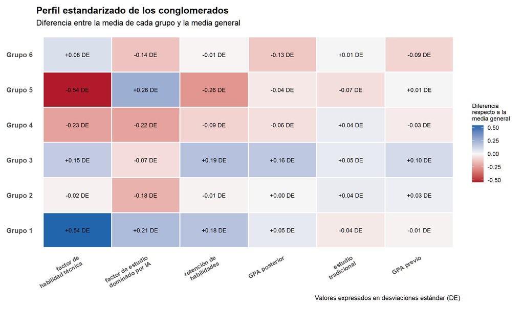

#### Visualizacion espacial de las estadisticas de las variables por grupo

[interactive chart not shown]

#### Lectura integrada de los perfiles

El mapa de calor permite identificar la dirección y magnitud de cada contraste, mientras que la vista tridimensional muestra la trayectoria conjunta de las seis variables dentro de cada conglomerado. A partir de ambos gráficos, los grupos se interpretan de la siguiente manera:

- **Grupo 1 — Usuarios intensivos de IA con alta habilidad técnica.** Es el perfil técnicamente más fuerte (+0.54 DE) y combina esa ventaja con mayor estudio dominado por IA (+0.21 DE), más horas semanales de uso (+0.22 DE) y retención superior (+0.18 DE). La etiqueta refleja un uso intenso acompañado por capacidad técnica, no solamente una mayor exposición a herramientas.
- **Grupo 2 — Usuarios moderados de IA con desempeño académico estable.** El estudio dominado por IA (-0.18 DE), las horas de uso (-0.18 DE) y la dependencia percibida (-0.13 DE) son inferiores al promedio, mientras GPA, retención, habilidad técnica y estudio tradicional permanecen muy cerca de la media. Es un perfil de uso contenido sin una desventaja académica marcada.
- **Grupo 3 — Estudiantes con rendimiento y retención superiores y uso moderado de IA.** Presenta la mayor retención (+0.19 DE), GPA posterior superior (+0.16 DE), habilidad técnica favorable (+0.15 DE) y GPA previo también superior (+0.10 DE), pese a utilizar IA ligeramente menos que el promedio (-0.07 DE). Es el grupo con el patrón académico más favorable y no depende de un uso intensivo para distinguirse.
- **Grupo 4 — Usuarios poco intensivos de IA con habilidad técnica inferior.** Reúne menor habilidad técnica (-0.23 DE), menor estudio dominado por IA (-0.22 DE), menos horas de uso (-0.23 DE) y menor dependencia percibida (-0.16 DE). La retención (-0.09 DE) y el GPA posterior (-0.06 DE) también se sitúan por debajo del promedio, aunque con diferencias pequeñas.
- **Grupo 5 — Usuarios intensivos y dependientes con baja habilidad técnica y retención.** Es el contraste más claro: registra la menor habilidad técnica (-0.54 DE) y menor retención (-0.26 DE), pero el mayor estudio dominado por IA (+0.26 DE), más horas semanales (+0.26 DE) y mayor dependencia percibida (+0.20 DE). La combinación describe uso elevado sin una competencia técnica o retención equivalente; no demuestra que la dependencia sea su causa.
- **Grupo 6 — Usuarios moderados-bajos de IA con rendimiento académico inferior.** Combina menos horas de IA (-0.14 DE), menor dependencia percibida (-0.10 DE), menor estudio dominado por IA y GPA posterior inferior (-0.13 DE). Se diferencia del grupo 4 porque su rasgo principal es el rendimiento académico más bajo, no una caída tan marcada de habilidad técnica.

En conjunto, los perfiles 1 y 5 muestran que una intensidad de uso semejante puede coexistir con resultados técnicos y de retención opuestos. Asimismo, los grupos 2, 4 y 6 confirman que usar menos IA no define por sí solo un perfil académico favorable o desfavorable. Por ello, los nombres resumen combinaciones observadas dentro de los conglomerados y no establecen que el uso o la dependencia de IA provoquen las calificaciones obtenidas.

## Discusión

### Síntesis descriptiva y bivariada

La muestra presenta heterogeneidad en uso de IA, estudio y resultados. El uso semanal de IA es asimétrico: la media (8.43) supera la mediana (5.8), compatible con un subconjunto de usuarios intensivos. El GPA posterior medio supera al previo en 0.203 puntos, pero esta comparación antes-después no controla otros cambios del semestre. La retención superior a 70 comprende 67.2 % de la muestra y describe una concentración en puntajes relativamente altos, sin identificar su causa.

El patrón bivariado más sólido es la asociación entre GPA previo y posterior ($r$ = 0.927, fuerte). Esto podría indicar persistencia del desempeño académico: la posición inicial del estudiante aporta más información sobre su GPA final que las asociaciones aisladas con uso de IA. Por otra parte, horas de IA se relacionan con dependencia ($r$ = 0.665) y ansiedad ($r$ = 0.269), pero sus asociaciones con retención y estudio tradicional son débil. Una posibilidad es que el uso intensivo acompañe necesidades académicas o dependencia percibida; otra es que esas condiciones impulsen el uso. El diseño observacional no establece la dirección. En las variables categóricas, la mayor $V$ de Cramer es 0.333 (moderada), por lo que los p-valores deben leerse como evidencia de asociación y no automáticamente como importancia práctica.

### Estructura factorial

La solución exploratoria resume 52 % de la varianza mediante dos factores. El primero reúne horas de IA, dependencia, ansiedad y burnout, por lo que podría representar una dimensión de estudio con mayor centralidad de la IA y carga psicoacadémica asociada. El segundo combina habilidad de *prompt engineering* y diversidad de herramientas, compatible con una dimensión de competencia técnica autopercibida. Estas denominaciones son resúmenes estadísticos, no diagnósticos personales.

El AFC evalúa esa estructura en la mitad reservada: $CFI$ = 0.991, $TLI$ = 0.985, $RMSEA$ = 0.033, $NFI$ = 0.995 y $GFI$ = 1. El patrón conjunto alcanza los criterios de referencia adoptados y respalda de manera aproximada la estructura de dos factores. Los puntajes factoriales incorporados a k-prototypes se obtienen después de este proceso; la segmentación no constituye otra confirmación del AFE o AFC.

### Segmentación y perfiles

La regla establecida seleccionó el candidato complementarias_con_factores__k6, con seis conglomerados, una silueta diagnóstica de 0.196, distancia total intragrupo de 22 207.44 y un grupo mínimo de 14.5 % en la submuestra. Esta elección ofrece un compromiso operativo entre diferenciación, equilibrio e interpretación, pero la separación es limitada; por ello los seis grupos se consideran una síntesis exploratoria y no clases nítidamente separadas. La selección se realizó sobre 15 000 estudiantes y el modelo final se reajustó sobre 50 000 registros. En ese ajuste, el grupo menor contiene 5 332 estudiantes (10.7 %) y el mayor 9 718 (19.4 %). La distribución evita grupos residuales extremadamente pequeños, aunque el balance no elimina el solapamiento señalado por la silueta.

El mapa de calor y la visualización tridimensional permiten interpretar cada conglomerado como una trayectoria conjunta de habilidad técnica, estudio dominado por IA, retención, GPA y estudio tradicional. Con base en esas diferencias respecto a la media general, los seis perfiles se resumen así:

- **Grupo 1 — Usuarios intensivos de IA con alta habilidad técnica.** Presenta la mayor habilidad técnica (+0.54 DE), junto con estudio dominado por IA (+0.21 DE), más horas semanales de uso (+0.22 DE) y retención superior (+0.18 DE). Este grupo representa un uso intensivo acompañado por capacidad técnica y no únicamente por una mayor exposición a las herramientas.
- **Grupo 2 — Usuarios moderados de IA con desempeño académico estable.** Las horas de IA (-0.18 DE), el estudio dominado por IA (-0.18 DE) y la dependencia percibida (-0.13 DE) son inferiores al promedio, mientras GPA, retención, habilidad técnica y estudio tradicional permanecen cercanos a la media. Es un perfil de uso contenido sin una desventaja académica marcada.
- **Grupo 3 — Estudiantes con rendimiento y retención superiores y uso moderado de IA.** Registra la mayor retención (+0.19 DE), GPA posterior superior (+0.16 DE), habilidad técnica favorable (+0.15 DE) y GPA previo también superior (+0.10 DE), aunque sus horas de IA son ligeramente menores al promedio (-0.07 DE). Es el patrón académico más favorable sin depender de un uso intensivo para distinguirse.
- **Grupo 4 — Usuarios poco intensivos de IA con habilidad técnica inferior.** Combina menor habilidad técnica (-0.23 DE), menor estudio dominado por IA (-0.22 DE), menos horas de uso (-0.23 DE) y menor dependencia percibida (-0.16 DE). La retención (-0.09 DE) y el GPA posterior (-0.06 DE) también son inferiores, aunque estas dos diferencias permanecen cercanas al promedio.
- **Grupo 5 — Usuarios intensivos y dependientes con baja habilidad técnica y retención.** Constituye el contraste más marcado: presenta la menor habilidad técnica (-0.54 DE) y retención (-0.26 DE), pero el mayor estudio dominado por IA (+0.26 DE), más horas semanales (+0.26 DE) y mayor dependencia percibida (+0.20 DE). El perfil describe un uso elevado sin una competencia técnica o retención equivalente, pero no demuestra que la dependencia produzca esos resultados.
- **Grupo 6 — Usuarios moderados-bajos de IA con rendimiento académico inferior.** Reúne menos horas de IA (-0.14 DE), menor dependencia percibida (-0.10 DE), menor estudio dominado por IA y GPA posterior inferior (-0.13 DE). A diferencia del grupo 4, su rasgo central es el desempeño académico inferior y no una reducción tan marcada de la habilidad técnica.

La comparación entre los grupos 1 y 5 es especialmente relevante: ambos usan IA con intensidad superior al promedio, pero exhiben perfiles opuestos de habilidad técnica y retención. Del mismo modo, los grupos 2, 4 y 6 muestran que un menor uso de IA puede coexistir con resultados académicos estables o inferiores. Por tanto, la intensidad de uso no explica por sí sola el desempeño; su interpretación depende de la habilidad técnica, la retención y la trayectoria académica que acompañan a cada perfil.

Estas etiquetas son síntesis descriptivas relativas al promedio general, no categorías estables ni relaciones causales. GPA, retención y los factores de uso participaron directa o indirectamente en la construcción de los conglomerados; por ello, las diferencias observadas caracterizan la segmentación, pero no la validan de manera independiente.

### Alcance de los hallazgos

Las asociaciones observadas no permiten establecer causalidad. K-prototypes combina distancias numéricas y categóricas; con `type = "gower"`, las variables numéricas se normalizan por rango, las nominales se comparan por coincidencia simple y las ordinales utilizan el orden de sus niveles. Además, los grupos incorporan resultados posteriores al semestre, por lo que son retrospectivos y no pueden utilizarse para predecir esos mismos resultados. Estas decisiones deben considerarse al interpretar diferencias entre perfiles.

# Salud Mental burnout

## Introducción y pregunta de análisis

En los entornos laborales y tecnológicos actuales, la sobrecarga digital y las exigencias continuas de rendimiento se han consolidado como factores críticos en la aparición del síndrome de agotamiento profesional (*burnout*). El estudio cuantitativo de estos indicadores permite a las organizaciones diseñar estrategias preventivas basadas en datos para mitigar el estrés digital.

**Pregunta de análisis:** ¿de qué manera interactúan la carga de trabajo semanal, la exposición a pantallas y el equilibrio vida-trabajo en la determinación del perfil sintomático del colaborador (ansiedad, depresión y agotamiento), es posible segmentar niveles de riesgo laboral a partir de esas variables, y qué tanto explican estos factores —frente a otros no medidos— la variación observada en el agotamiento?

## Descripción de la base de datos

**Fuente:** Fatima, M. (2026). *Mental Health & Burnout Prediction Dataset* [Dataset]. Repositorio Kaggle.

**Licencia / acceso:** Open Data / Community Data License Agreement (CC BY 4.0) — de acceso público y libre.

El conjunto contiene **50,000 observaciones** (una por colaborador) y **40 variables**. La tabla siguiente resume las variables efectivamente usadas en el análisis:

| Variable original | Variable en este documento | Significado | Tipo |
| --- | --- | --- | --- |
| Age | Edad | Edad del colaborador | Numérica |
| Employment_Status | Situacion_Laboral | Situación laboral (Employed / Self-Employed / Student / Unemployed) | Categórica |
| Remote_Work | Modalidad_Trabajo | Modalidad de trabajo (presencial / remoto / híbrido) | Categórica |
| Work_Hours_Per_Week | Horas_Trabajo_Semana | Horas trabajadas por semana | Numérica |
| Screen_Time_Hours | Horas_Pantalla | Horas diarias frente a pantallas | Numérica |
| Social_Media_Hours | Horas_Redes_Sociales | Horas diarias en redes sociales | Numérica |
| Sleep_Hours | Horas_Sueno | Horas de sueño por noche | Numérica |
| Sleep_Quality | Calidad_Sueno | Calidad de sueño autopercibida (Poor/Average/Good/Excellent) | Categórica |
| Work_Life_Balance | Equilibrio_Vida_Trabajo | Equilibrio vida-trabajo autopercibido (1-10) | Numérica |
| Anxiety_Score | Puntaje_Ansiedad | Puntaje de ansiedad (0-100) | Numérica |
| Depression_Score | Puntaje_Depresion | Puntaje de depresión (0-100) | Numérica |
| Burnout_Score | Puntaje_Agotamiento | Puntaje de agotamiento — **variable de interés central** (0-100) | Numérica |
| Productivity_Score | Puntaje_Productividad | Productividad autopercibida (0-100) | Numérica |
| Job_Satisfaction | Satisfaccion_Laboral | Satisfacción laboral autopercibida (1-10) | Numérica |

## Extracción y preparación de los datos

```r
# Extracción y limpieza — Data/mental_health_burnout_prediction_dataset.csv
# (mice, corrplot y tidyr ya se cargaron en el setup global)

# 1. Carga del conjunto de datos
df_burnout_raw <- read.csv("Data/mental_health_burnout_prediction_dataset.csv",
                            stringsAsFactors = TRUE)

dim(df_burnout_raw)
```

```
## [1] 50000    40
```

```r
# Renombrado al español de las variables usadas en el análisis (ver tabla
# "Variable original -> Variable en este documento" de la sección anterior).
# Las columnas no usadas en el análisis conservan su nombre original.
df_burnout_raw <- df_burnout_raw %>%
  rename(
    Edad                    = Age,
    Situacion_Laboral       = Employment_Status,
    Modalidad_Trabajo       = Remote_Work,
    Horas_Trabajo_Semana    = Work_Hours_Per_Week,
    Horas_Pantalla          = Screen_Time_Hours,
    Horas_Redes_Sociales    = Social_Media_Hours,
    Horas_Sueno             = Sleep_Hours,
    Calidad_Sueno           = Sleep_Quality,
    Equilibrio_Vida_Trabajo = Work_Life_Balance,
    Puntaje_Ansiedad        = Anxiety_Score,
    Puntaje_Depresion       = Depression_Score,
    Puntaje_Agotamiento     = Burnout_Score,
    Puntaje_Productividad   = Productivity_Score,
    Satisfaccion_Laboral    = Job_Satisfaction
  )

str(df_burnout_raw[, c("Edad", "Situacion_Laboral", "Modalidad_Trabajo",
                        "Horas_Trabajo_Semana", "Calidad_Sueno",
                        "Puntaje_Agotamiento")])
```

```
## 'data.frame':    50000 obs. of  6 variables:
##  $ Edad                : num  58 24 59 65 64 48 33 22 50 24 ...
##  $ Situacion_Laboral   : Factor w/ 4 levels "Employed","Self-Employed",..: 1 3 1 2 3 4 1 3 3 2 ...
##  $ Modalidad_Trabajo   : Factor w/ 3 levels "Hybrid","No",..: 1 1 2 3 2 1 1 3 3 2 ...
##  $ Horas_Trabajo_Semana: int  67 44 60 25 52 64 70 51 63 35 ...
##  $ Calidad_Sueno       : Factor w/ 4 levels "Average","Excellent",..: 4 4 1 3 2 3 1 1 3 2 ...
##  $ Puntaje_Agotamiento : int  82 64 50 16 26 68 41 49 16 16 ...
```

```r
summary(df_burnout_raw[, c("Horas_Trabajo_Semana", "Horas_Pantalla",
                            "Horas_Sueno", "Puntaje_Agotamiento")])
```

```
##  Horas_Trabajo_Semana Horas_Pantalla    Horas_Sueno     Puntaje_Agotamiento
##  Min.   :20.00        Min.   : 2.000   Min.   : 4.000   Min.   :  0.0
##  1st Qu.:32.00        1st Qu.: 5.000   1st Qu.: 5.500   1st Qu.: 19.0
##  Median :45.00        Median : 8.000   Median : 7.000   Median : 39.0
##  Mean   :44.95        Mean   : 7.991   Mean   : 6.997   Mean   : 40.2
##  3rd Qu.:58.00        3rd Qu.:11.000   3rd Qu.: 8.500   3rd Qu.: 59.0
##  Max.   :70.00        Max.   :14.000   Max.   :10.000   Max.   :100.0
##                       NA's   :850      NA's   :950
```

```r
# 2. Duplicados y valores faltantes
sum(duplicated(df_burnout_raw))
```

```
## [1] 0
```

```r
resumen_na <- df_burnout_raw %>%
  summarise(across(everything(), ~ sum(is.na(.)))) %>%
  pivot_longer(everything(), names_to = "Variable", values_to = "NA_count") %>%
  filter(NA_count > 0) %>%
  arrange(desc(NA_count))

cat("Total de datos faltantes:", sum(is.na(df_burnout_raw)),
    "(", round(100 * sum(is.na(df_burnout_raw)) / (nrow(df_burnout_raw) * ncol(df_burnout_raw)), 2),
    "% de las celdas ) en", nrow(resumen_na), "de", ncol(df_burnout_raw), "variables\n")
```

```
## Total de datos faltantes: 12500 ( 0.62 % de las celdas ) en 15 de 40 variables
```

```r
resumen_na
```

| Variable | NA_count |
| --- | --- |
| Monthly_Income_USD | 1450 |
| Meditation_Minutes | 1200 |
| Physical_Activity_Hours | 1100 |
| Horas_Sueno | 950 |
| Puntaje_Productividad | 950 |
| Mood_Score | 900 |
| Puntaje_Depresion | 850 |
| Horas_Pantalla | 850 |
| Puntaje_Ansiedad | 800 |
| Gaming_Hours | 750 |
| Life_Satisfaction | 700 |
| Equilibrio_Vida_Trabajo | 650 |
| Horas_Redes_Sociales | 600 |
| Satisfaccion_Laboral | 500 |
| Edad | 250 |

```r
# 3. Verificación de los factores categóricos clave
table(df_burnout_raw$Calidad_Sueno)
```

```
##
##   Average Excellent      Good      Poor
##     16626      8646     16852      7876
```

```r
table(df_burnout_raw$Situacion_Laboral)
```

```
##
##      Employed Self-Employed       Student    Unemployed
##         12414         12366         12520         12700
```

```r
# 4. Imputación MICE (Predictive Mean Matching)
set.seed(123)
imp_model <- mice(df_burnout_raw, m = 1, method = "pmm", printFlag = FALSE)
df_burnout_clean <- complete(imp_model)

sum(is.na(df_burnout_clean))
```

```
## [1] 0
```

Interpretación de la limpieza y preparación: el conjunto tiene 50,000 observaciones, 40 variables y ningún registro duplicado.

Los valores faltantes se concentran de forma dispersa en varias variables numéricas y no superan un pequeño porcentaje del total de celdas, por lo que se optó por imputar en vez de eliminar registros.

La imputación se realizó mediante Imputación Múltiple por Ecuaciones Encadenadas (MICE, método PMM — *Predictive Mean Matching*), que reemplaza cada faltante por un valor observado “plausible” tomado de registros similares, preservando la distribución original de cada variable (a diferencia de imputar con la media, que la distorsiona). Tras el proceso, `df_burnout_clean` queda sin datos faltantes y es la base para el resto del análisis.

## Exploración de los datos (EDA)

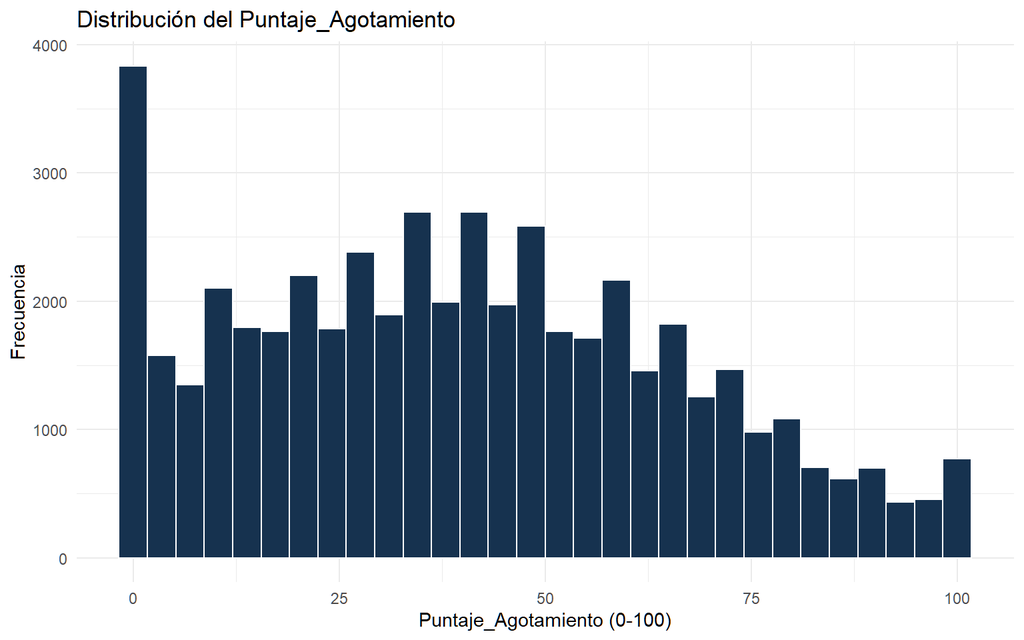

```r
# Distribución de la variable objetivo
ggplot(df_burnout_clean, aes(x = Puntaje_Agotamiento)) +
  geom_histogram(bins = 30, fill = col_navy, color = "white") +
  labs(title = "Distribución del Puntaje_Agotamiento",
       x = "Puntaje_Agotamiento (0-100)", y = "Frecuencia") +
  theme_minimal()
```

```r
# Matriz de correlaciones entre variables numéricas clave
num_vars_burnout <- df_burnout_clean %>%
  select(Horas_Trabajo_Semana, Horas_Pantalla, Puntaje_Ansiedad,
         Puntaje_Depresion, Puntaje_Agotamiento, Equilibrio_Vida_Trabajo, Puntaje_Productividad)

round(cor(num_vars_burnout), 3)
```

```
##                         Horas_Trabajo_Semana Horas_Pantalla Puntaje_Ansiedad
## Horas_Trabajo_Semana                   1.000         -0.001            0.624
## Horas_Pantalla                        -0.001          1.000            0.360
## Puntaje_Ansiedad                       0.624          0.360            1.000
## Puntaje_Depresion                      0.613          0.347            0.913
## Puntaje_Agotamiento                    0.608          0.350            0.924
## Equilibrio_Vida_Trabajo               -0.003         -0.003            0.000
## Puntaje_Productividad                 -0.614         -0.354           -0.916
##                         Puntaje_Depresion Puntaje_Agotamiento
## Horas_Trabajo_Semana                0.613               0.608
## Horas_Pantalla                      0.347               0.350
## Puntaje_Ansiedad                    0.913               0.924
## Puntaje_Depresion                   1.000               0.911
## Puntaje_Agotamiento                 0.911               1.000
## Equilibrio_Vida_Trabajo            -0.001               0.000
## Puntaje_Productividad              -0.899              -0.893
##                         Equilibrio_Vida_Trabajo Puntaje_Productividad
## Horas_Trabajo_Semana                     -0.003                -0.614
## Horas_Pantalla                           -0.003                -0.354
## Puntaje_Ansiedad                          0.000                -0.916
## Puntaje_Depresion                        -0.001                -0.899
## Puntaje_Agotamiento                       0.000                -0.893
## Equilibrio_Vida_Trabajo                   1.000                 0.002
## Puntaje_Productividad                     0.002                 1.000
```

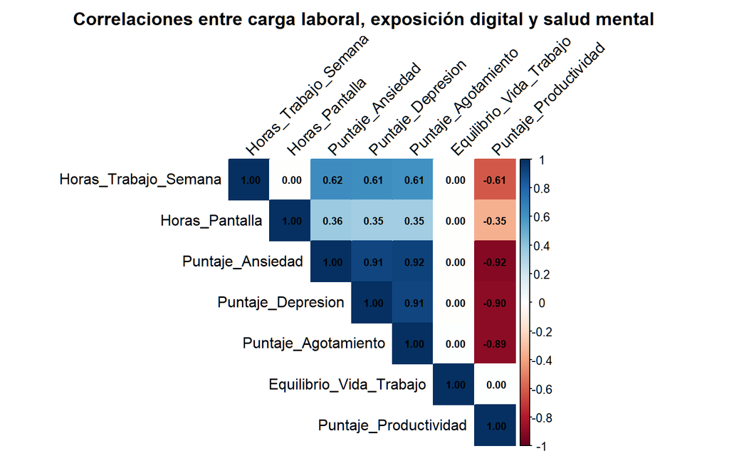

```r
corrplot(cor(num_vars_burnout), method = "color", type = "upper",
         tl.col = "black", tl.srt = 45, addCoef.col = "black",
         number.cex = 0.7,
         title = "Correlaciones entre carga laboral, exposición digital y salud mental",
         mar = c(0, 0, 2, 0))
```

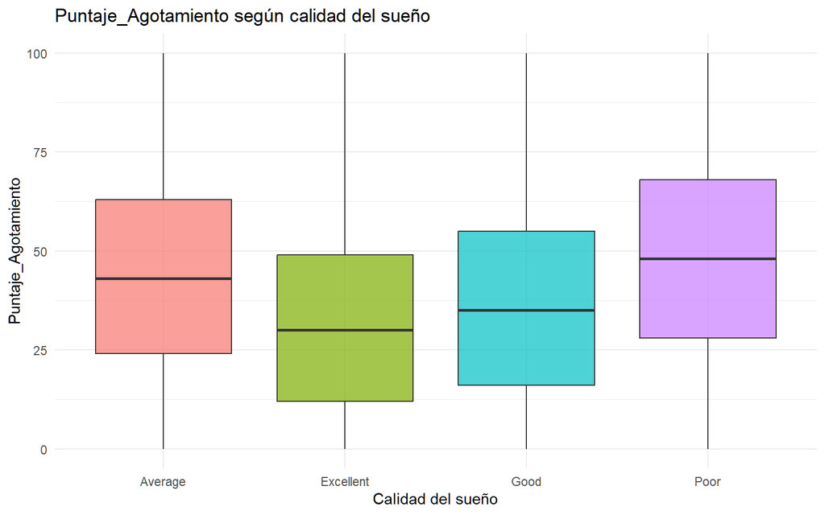

```r
# Puntaje_Agotamiento según calidad del sueño (motiva la Técnica 1 - MANOVA)
ggplot(df_burnout_clean, aes(x = Calidad_Sueno, y = Puntaje_Agotamiento, fill = Calidad_Sueno)) +
  geom_boxplot(alpha = 0.7) +
  labs(title = "Puntaje_Agotamiento según calidad del sueño",
       x = "Calidad del sueño", y = "Puntaje_Agotamiento") +
  theme_minimal() +
  theme(legend.position = "none")
```

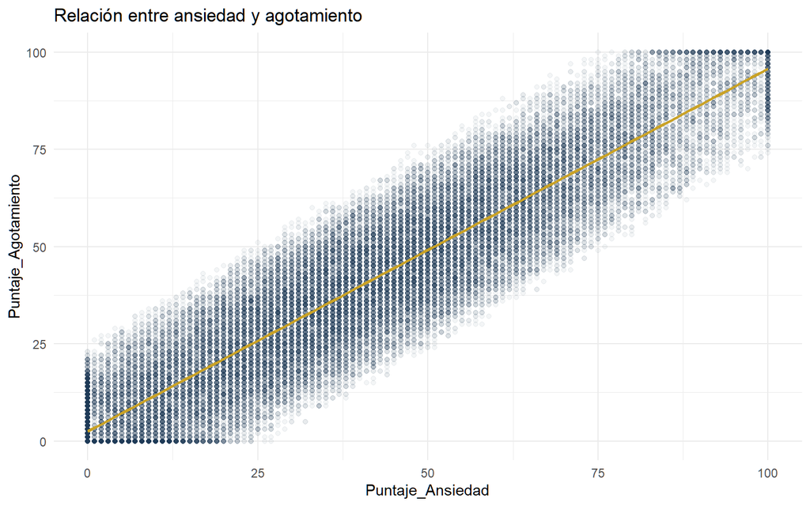

```r
# Relación Puntaje_Ansiedad - Puntaje_Agotamiento (motiva la Técnica 3 - regresión)
ggplot(df_burnout_clean, aes(x = Puntaje_Ansiedad, y = Puntaje_Agotamiento)) +
  geom_point(alpha = 0.05, color = col_navy) +
  geom_smooth(method = "lm", color = "#C9A227", se = FALSE) +
  labs(title = "Relación entre ansiedad y agotamiento",
       x = "Puntaje_Ansiedad", y = "Puntaje_Agotamiento") +
  theme_minimal()
```

La matriz de correlaciones confirma que Puntaje_Ansiedad, Puntaje_Depresion y Puntaje_Agotamiento están fuertemente intercorrelacionados entre sí (r ≈ 0.91-0.92), lo cual justifica tratarlos como un único perfil sintomático multivariado (ver MANOVA, Técnica 1).

Horas_Trabajo_Semana (r ≈ 0.61) y, en menor medida, Horas_Pantalla (r ≈ 0.35-0.36) muestran una correlación positiva moderada con ese perfil, y ambas se correlacionan negativamente con Puntaje_Productividad (r ≈ -0.61 y -0.36), evidenciando el costo productivo del agotamiento.

El boxplot por calidad de sueño ya deja ver un gradiente claro (Excellent < Good < Average < Poor) que se confirma estadísticamente más adelante.

Un hallazgo que **contradice la intuición inicial** es que Equilibrio_Vida_Trabajo presenta una correlación prácticamente nula (r ≈ 0.00) con el resto de variables en este conjunto de datos: no se comporta como factor protector aquí, lo que se retoma en la regresión (Técnica 3) y en la discusión de limitaciones.

## Modelos aplicados

### Técnica 1 — Análisis Multivariado de Varianza (MANOVA)

La pregunta de análisis requiere entender el “perfil sintomático” del colaborador, formado simultáneamente por ansiedad, depresión y agotamiento. Evaluar estas tres variables con ANOVAs separados inflaría el error tipo I y, sobre todo, ignoraría que están fuertemente correlacionadas entre sí (r ≈ 0.91-0.92, según el EDA), es decir, no aportan información independiente. El MANOVA es la técnica apropiada porque contrasta el efecto de un factor categórico (`Calidad_Sueno`) sobre el **vector conjunto** de las tres variables de salud emocional, controlando esa correlación y respondiendo directamente si la calidad del sueño diferencia el perfil sintomático completo, no solo una de sus componentes.

```r
# Matriz multivariada de respuesta y modelo MANOVA
Y_matriz <- cbind(df_burnout_clean$Puntaje_Agotamiento,
                   df_burnout_clean$Puntaje_Ansiedad,
                   df_burnout_clean$Puntaje_Depresion)

modelo_manova <- manova(Y_matriz ~ Calidad_Sueno, data = df_burnout_clean)
summary(modelo_manova, test = "Pillai")
```

```
##                  Df   Pillai approx F num Df den Df    Pr(>F)
## Calidad_Sueno     3 0.049705   280.77      9 149988 < 2.2e-16 ***
## Residuals     49996
## ---
## Signif. codes:  0 '***' 0.001 '**' 0.01 '*' 0.05 '.' 0.1 ' ' 1
```

```r
# Seguimiento univariado: ¿el efecto se sostiene en cada síntoma por separado?
summary(aov(Puntaje_Agotamiento ~ Calidad_Sueno, data = df_burnout_clean))
```

```
##                  Df   Sum Sq Mean Sq F value Pr(>F)
## Calidad_Sueno     3  1561857  520619   793.1 <2e-16 ***
## Residuals     49996 32820057     656
## ---
## Signif. codes:  0 '***' 0.001 '**' 0.01 '*' 0.05 '.' 0.1 ' ' 1
```

```r
summary(aov(Puntaje_Ansiedad ~ Calidad_Sueno, data = df_burnout_clean))
```

```
##                  Df   Sum Sq Mean Sq F value Pr(>F)
## Calidad_Sueno     3  1606566  535522   832.9 <2e-16 ***
## Residuals     49996 32144567     643
## ---
## Signif. codes:  0 '***' 0.001 '**' 0.01 '*' 0.05 '.' 0.1 ' ' 1
```

```r
summary(aov(Puntaje_Depresion ~ Calidad_Sueno, data = df_burnout_clean))
```

```
##                  Df   Sum Sq Mean Sq F value Pr(>F)
## Calidad_Sueno     3  1624118  541373   821.8 <2e-16 ***
## Residuals     49996 32936908     659
## ---
## Signif. codes:  0 '***' 0.001 '**' 0.01 '*' 0.05 '.' 0.1 ' ' 1
```

```r
# Medias del perfil sintomático por categoría de calidad del sueño
medias_sueno <- df_burnout_clean %>%
  group_by(Calidad_Sueno) %>%
  summarise(
    Puntaje_Agotamiento = mean(Puntaje_Agotamiento),
    Puntaje_Ansiedad    = mean(Puntaje_Ansiedad),
    Puntaje_Depresion   = mean(Puntaje_Depresion)
  ) %>%
  arrange(Puntaje_Agotamiento)
medias_sueno
```

| Calidad_Sueno | Puntaje_Agotamiento | Puntaje_Ansiedad | Puntaje_Depresion |
| --- | --- | --- | --- |
| Excellent | 32.01550 | 32.11878 | 32.37416 |
| Good | 36.70644 | 36.93057 | 36.94737 |
| Average | 44.17461 | 44.44797 | 44.69379 |
| Poor | 48.28136 | 48.66849 | 48.84662 |

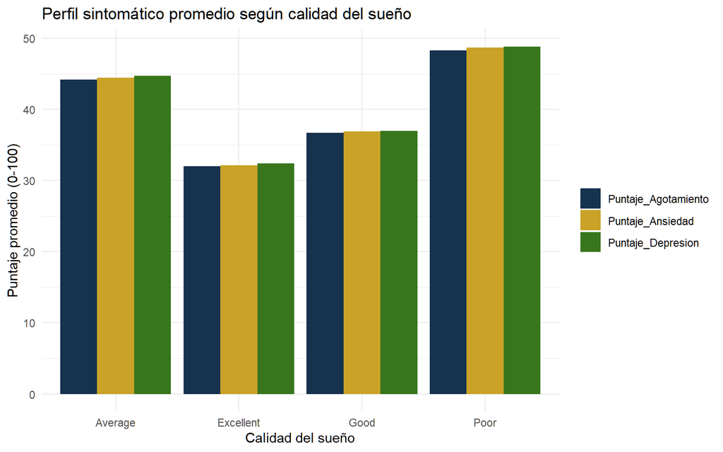

```r
# Visualización del perfil sintomático conjunto por grupo
medias_sueno %>%
  pivot_longer(-Calidad_Sueno, names_to = "Indicador", values_to = "Promedio") %>%
  ggplot(aes(x = Calidad_Sueno, y = Promedio, fill = Indicador)) +
  geom_col(position = "dodge") +
  scale_fill_manual(values = c(col_navy, "#C9A227", col_teal)) +
  labs(title = "Perfil sintomático promedio según calidad del sueño",
       x = "Calidad del sueño", y = "Puntaje promedio (0-100)", fill = NULL) +
  theme_minimal()
```

El estadístico de Pillai resulta significativo (p < 0.001), por lo que se rechaza la hipótesis nula: `Calidad_Sueno` sí tiene un efecto sobre el vector conjunto de Puntaje_Agotamiento, Puntaje_Ansiedad y Puntaje_Depresion.

La tabla de medias y el gráfico de barras muestran un gradiente claro y consistente en las cuatro categorías: quienes reportan sueño “Excellent” presentan los promedios más bajos en los tres indicadores, seguidos por “Good”, luego “Average”, y finalmente “Poor” con los promedios más altos —una diferencia de aproximadamente 15-17 puntos entre los extremos “Excellent” y “Poor” en cada variable—.

### Técnica 2 — Clustering: Segmentación $k$-Means

La segunda parte de la pregunta de análisis pide “segmentar niveles de riesgo laboral” en la población, sin partir de una etiqueta de grupo predefinida. $k$-Means es apropiado porque es un método de aprendizaje **no supervisado** que descubre agrupaciones naturales a partir de la similitud entre observaciones en varias variables continuas simultáneamente (carga horaria, exposición a pantallas, equilibrio vida-trabajo y agotamiento), permitiendo perfilar colaboradores de riesgo bajo, medio y alto sin necesidad de una variable de respuesta previa.

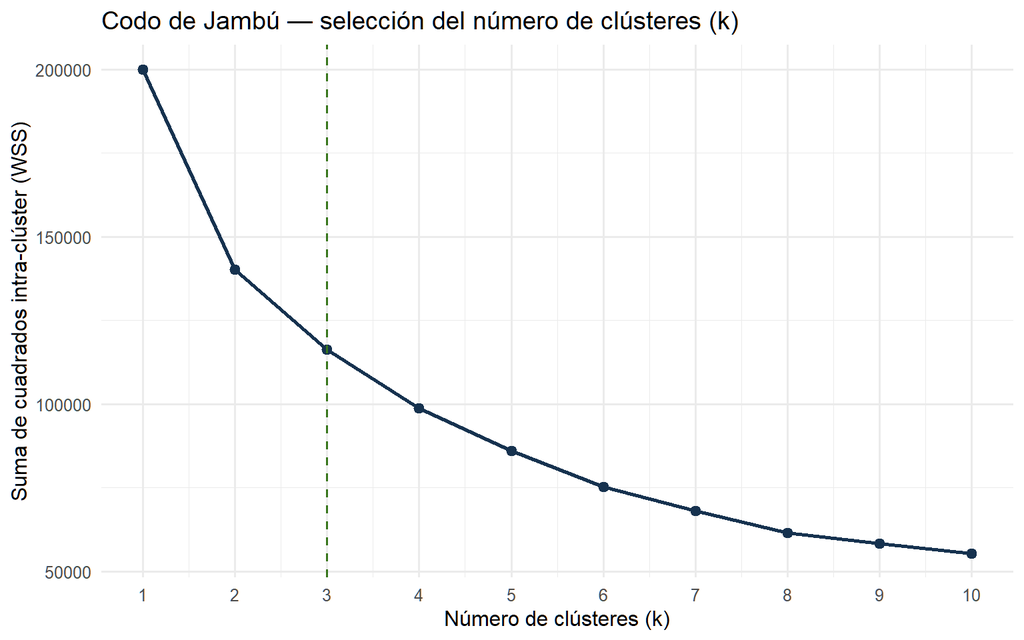

```r
# Selección y estandarización de las variables de entrada
df_cluster_input <- df_burnout_clean %>%
  select(Horas_Trabajo_Semana, Horas_Pantalla, Equilibrio_Vida_Trabajo, Puntaje_Agotamiento) %>%
  scale()

# --- Codo de Jambú (Elbow Method) para elegir k ---
# NOTA: fviz_nbclust() calcula internamente una matriz de distancias completa
# (dist()) sin importar el método, lo cual es inviable con 50,000 observaciones
# (~1.25 mil millones de pares) y provoca un error de desbordamiento. Por eso
# el WSS se calcula manualmente con un loop de kmeans() -que no requiere
# matriz de distancias- y se grafica con ggplot2.
set.seed(123)
k_max <- 10
wss <- sapply(1:k_max, function(k) {
  kmeans(df_cluster_input, centers = k, nstart = 10)$tot.withinss
})

df_codo <- data.frame(k = 1:k_max, wss = wss)

ggplot(df_codo, aes(x = k, y = wss)) +
  geom_line(color = col_navy, linewidth = 0.9) +
  geom_point(color = col_navy, size = 2.2) +
  geom_vline(xintercept = 3, linetype = "dashed", color = col_teal) +
  scale_x_continuous(breaks = 1:k_max) +
  labs(title = "Codo de Jambú — selección del número de clústeres (k)",
       x = "Número de clústeres (k)",
       y = "Suma de cuadrados intra-clúster (WSS)") +
  theme_minimal(base_size = 12)
```

**Elección de $k$:** la curva del codo de Jambú desciende con fuerza entre $k=1$ y $k=3$ (reducción de la inercia total de aproximadamente 42 %) y luego empieza a aplanarse: entre $k=3$ y $k=4$ la mejora ya es notablemente menor y, de ahí en adelante, cada clúster adicional agrega complejidad sin una ganancia proporcional. Ese “codo” alrededor de $k=3$ es el punto de equilibrio entre parsimonia (pocos grupos, fáciles de interpretar y de convertir en política institucional) y calidad del ajuste, por lo que se selecciona $k=3$ para representar niveles de riesgo bajo, medio y alto.

```r
# Agrupamiento k-Means con k = 3 grupos (según el codo de Jambú anterior)
set.seed(123)
km_fit <- kmeans(df_cluster_input, centers = 3, nstart = 25)
# Resumen del ajuste SIN imprimir el vector de asignación completo (50,000
# valores): km_fit por sí solo (o print(km_fit)) sí lo imprimiría, así que
# se extraen solo los campos de resumen relevantes del objeto kmeans.
cat("Tamaño de cada clúster:", paste(km_fit$size, collapse = ", "), "\n")
```

```
## Tamaño de cada clúster: 14024, 17329, 18647
```

```r
cat("between_SS / total_SS  :",
    round(100 * km_fit$betweenss / km_fit$totss, 1), "%\n")
```

```
## between_SS / total_SS  : 41.9 %
```

```r
# Muestra ilustrativa del vector de asignación (primeras 20 observaciones),
# en vez de imprimir las 50,000 filas completas
# Muestra ilustrativa del vector de asignación de clúster (formato nativo de
# R: vector indexado que se ajusta solo al ancho de línea), en vez de las
# 50,000 observaciones completas
cat("Vector de asignación de clúster (muestra de las primeras 200 observaciones):\n")
```

```
## Vector de asignación de clúster (muestra de las primeras 200 observaciones):
```

```r
head(km_fit$cluster, 200)
```

```
##   [1] 3 3 3 2 2 3 3 3 2 2 3 2 2 3 1 3 2 2 2 2 1 2 3 2 3 3 1 3 2 1 1 3 1 1 2 2 3
##  [38] 2 2 1 2 2 1 3 1 1 3 3 3 2 1 3 2 1 2 2 3 2 1 2 1 2 3 1 1 1 1 2 2 1 2 2 1 2
##  [75] 3 3 3 2 2 1 3 1 3 2 1 1 3 3 2 2 1 3 2 3 3 2 2 2 2 1 2 3 1 3 2 1 2 2 2 3 2
## [112] 2 3 3 2 1 1 1 3 2 1 1 1 2 1 1 3 3 3 2 3 2 1 1 3 1 2 2 3 2 1 3 1 1 2 3 2 3
## [149] 3 1 3 3 2 1 1 3 3 1 3 1 3 2 2 2 1 2 3 3 3 3 3 2 1 1 2 3 3 3 2 2 3 3 2 1 3
## [186] 3 3 2 2 1 2 1 2 2 2 2 3 3 3 3
```

```r
# Centroides por clúster en la escala original
df_burnout_clean$Cluster <- as.factor(km_fit$cluster)
df_burnout_clean %>%
  group_by(Cluster) %>%
  summarise(
    n = n(),
    across(c(Horas_Trabajo_Semana, Horas_Pantalla, Equilibrio_Vida_Trabajo, Puntaje_Agotamiento), mean)
  ) %>%
  arrange(Puntaje_Agotamiento)
```

| Cluster | n | Horas_Trabajo_Semana | Horas_Pantalla | Equilibrio_Vida_Trabajo | Puntaje_Agotamiento |
| --- | --- | --- | --- | --- | --- |
| 2 | 17329 | 39.45548 | 4.648866 | 5.596630 | 20.16481 |
| 1 | 14024 | 33.16065 | 10.852688 | 5.404521 | 31.70408 |
| 3 | 18647 | 58.91237 | 8.948174 | 5.490052 | 65.21371 |

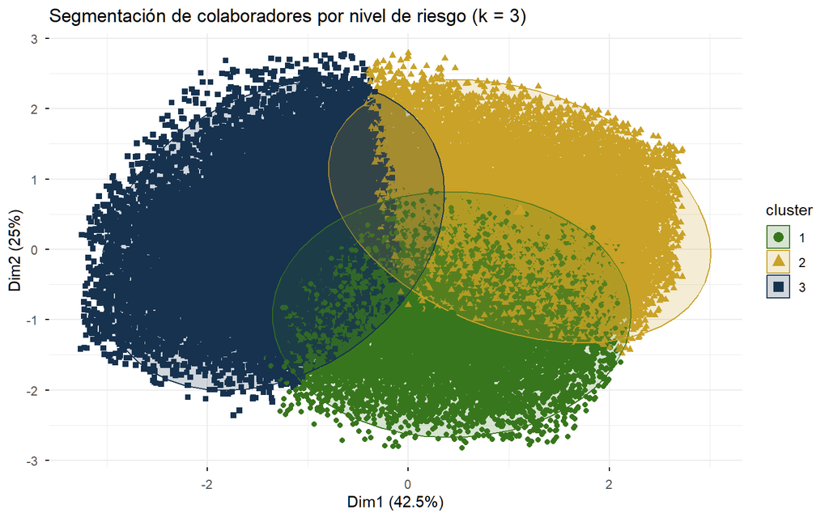

```r
# Visualización de los clústeres sobre las dos primeras componentes principales
fviz_cluster(km_fit, data = df_cluster_input, geom = "point", ellipse.type = "norm",
             palette = c(col_teal, "#C9A227", col_navy),
             ggtheme = theme_minimal(),
             main = "Segmentación de colaboradores por nivel de riesgo (k = 3)")
```

```r
# Validación cruzada contra variables categóricas NO usadas en el clustering
round(prop.table(table(df_burnout_clean$Cluster, df_burnout_clean$Calidad_Sueno), 1), 2)
```

```
##
##     Average Excellent Good Poor
##   1    0.32      0.18 0.35 0.15
##   2    0.31      0.19 0.36 0.14
##   3    0.36      0.15 0.31 0.18
```

```r
round(prop.table(table(df_burnout_clean$Cluster, df_burnout_clean$Situacion_Laboral), 1), 2)
```

```
##
##     Employed Self-Employed Student Unemployed
##   1     0.25          0.24    0.25       0.26
##   2     0.25          0.25    0.25       0.25
##   3     0.25          0.25    0.25       0.25
```

Los tres clústeres resultantes son razonablemente equilibrados en tamaño (entre ~14,000 y ~19,000 colaboradores cada uno), con un between_SS/total_SS cercano al 42 % —una separación moderada— y se diferencian sobre todo por carga horaria, tiempo de pantalla y agotamiento, no por Equilibrio_Vida_Trabajo, cuyo promedio es casi idéntico en los tres grupos.

Esto es un hallazgo honesto que vale la pena señalar como limitación (ver Discusión) más que forzar una narrativa de asociación que los datos no respaldan.

### Técnica 3 — Regresión Lineal Múltiple (lm)

El MANOVA y el $k$-Means identifican *que* existen diferencias y grupos de riesgo, pero no cuantifican el peso relativo de cada predictor sobre Puntaje_Agotamiento ni permiten estimar el agotamiento esperado para un colaborador con características particulares. La regresión lineal múltiple es la técnica apropiada para ese último tramo de la pregunta de análisis: modela Puntaje_Agotamiento como función continua de la carga horaria, el tiempo de pantalla, las horas de sueño, el equilibrio vida-trabajo y la ansiedad, cuantificando la dirección y magnitud (coeficientes) de cada relación y evaluando la calidad global del ajuste ($R^2$).

```r
# Modelo completo
modelo_reg_completo <- lm(Puntaje_Agotamiento ~ Horas_Trabajo_Semana + Horas_Pantalla +
                            Horas_Sueno + Equilibrio_Vida_Trabajo + Puntaje_Ansiedad,
                          data = df_burnout_clean)
summary(modelo_reg_completo)
```

```
##
## Call:
## lm(formula = Puntaje_Agotamiento ~ Horas_Trabajo_Semana + Horas_Pantalla +
##     Horas_Sueno + Equilibrio_Vida_Trabajo + Puntaje_Ansiedad,
##     data = df_burnout_clean)
##
## Residuals:
##      Min       1Q   Median       3Q      Max
## -27.7011  -7.2646  -0.3058   7.4273  28.8815
##
## Coefficients:
##                          Estimate Std. Error t value Pr(>|t|)
## (Intercept)             -0.384273   0.265225  -1.449    0.147
## Horas_Trabajo_Semana     0.129695   0.004158  31.192   <2e-16 ***
## Horas_Pantalla           0.305597   0.014551  21.001   <2e-16 ***
## Horas_Sueno             -0.394530   0.027152 -14.530   <2e-16 ***
## Equilibrio_Vida_Trabajo  0.006977   0.015437   0.452    0.651
## Puntaje_Ansiedad         0.866244   0.002605 332.475   <2e-16 ***
## ---
## Signif. codes:  0 '***' 0.001 '**' 0.01 '*' 0.05 '.' 0.1 ' ' 1
##
## Residual standard error: 9.901 on 49994 degrees of freedom
## Multiple R-squared:  0.8574, Adjusted R-squared:  0.8574
## F-statistic: 6.014e+04 on 5 and 49994 DF,  p-value: < 2.2e-16
```

```r
vif(modelo_reg_completo)
```

```
##    Horas_Trabajo_Semana          Horas_Pantalla             Horas_Sueno
##                1.912872                1.302280                1.124395
## Equilibrio_Vida_Trabajo        Puntaje_Ansiedad
##                1.000038                2.336955
```

```r
# Equilibrio_Vida_Trabajo no resultó significativo (ver interpretación): se compara
# contra un modelo reducido sin esa variable, igual que se hizo con
# Punto_Rocio en la pestaña de SeoulBikeData.
modelo_reg_final <- lm(Puntaje_Agotamiento ~ Horas_Trabajo_Semana + Horas_Pantalla +
                         Horas_Sueno + Puntaje_Ansiedad,
                       data = df_burnout_clean)
summary(modelo_reg_final)
```

```
##
## Call:
## lm(formula = Puntaje_Agotamiento ~ Horas_Trabajo_Semana + Horas_Pantalla +
##     Horas_Sueno + Puntaje_Ansiedad, data = df_burnout_clean)
##
## Residuals:
##      Min       1Q   Median       3Q      Max
## -27.7184  -7.2673  -0.3093   7.4296  28.8500
##
## Coefficients:
##                       Estimate Std. Error t value Pr(>|t|)
## (Intercept)          -0.345392   0.250882  -1.377    0.169
## Horas_Trabajo_Semana  0.129686   0.004158  31.190   <2e-16 ***
## Horas_Pantalla        0.305567   0.014551  21.000   <2e-16 ***
## Horas_Sueno          -0.394530   0.027152 -14.530   <2e-16 ***
## Puntaje_Ansiedad      0.866249   0.002605 332.482   <2e-16 ***
## ---
## Signif. codes:  0 '***' 0.001 '**' 0.01 '*' 0.05 '.' 0.1 ' ' 1
##
## Residual standard error: 9.901 on 49995 degrees of freedom
## Multiple R-squared:  0.8574, Adjusted R-squared:  0.8574
## F-statistic: 7.518e+04 on 4 and 49995 DF,  p-value: < 2.2e-16
```

```r
vif(modelo_reg_final)
```

```
## Horas_Trabajo_Semana       Horas_Pantalla          Horas_Sueno
##             1.912822             1.302252             1.124395
##     Puntaje_Ansiedad
##             2.336916
```

```r
AIC(modelo_reg_completo, modelo_reg_final)
```

|  | df | AIC |
| --- | --- | --- |
| modelo_reg_completo | 7 | 371170.2 |
| modelo_reg_final | 6 | 371168.4 |

```r
BIC(modelo_reg_completo, modelo_reg_final)
```

|  | df | BIC |
| --- | --- | --- |
| modelo_reg_completo | 7 | 371232.0 |
| modelo_reg_final | 6 | 371221.3 |

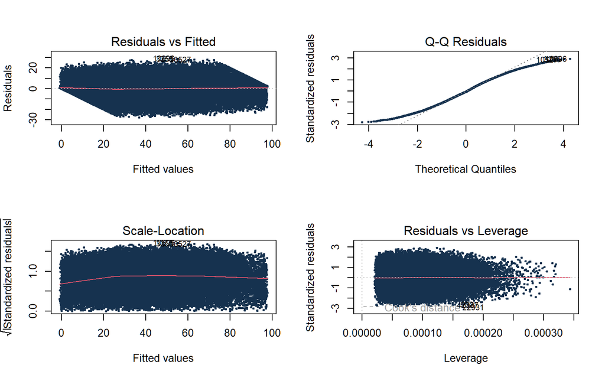

```r
par(mfrow = c(2, 2))
plot(modelo_reg_final, col = col_navy, pch = 19, cex = 0.4)
```

```r
par(mfrow = c(1, 1))

# Ejemplo de predicción: colaborador con jornada larga, alta exposición a
# pantallas, poco sueño y ansiedad alta
nuevo_colaborador <- data.frame(Horas_Trabajo_Semana = 55, Horas_Pantalla = 9,
                                 Horas_Sueno = 5.5, Puntaje_Ansiedad = 70)
predict(modelo_reg_final, newdata = nuevo_colaborador, interval = "prediction")
```

```
##        fit      lwr      upr
## 1 68.00492 48.59755 87.41229
```

El modelo completo explica una proporción muy alta de la varianza de Puntaje_Agotamiento ($R^2$ ajustado ≈ 0.858), y todos los VIF se mantienen por debajo de 2.5, por lo que no hay evidencia de multicolinealidad problemática entre los predictores.

Los gráficos de diagnóstico del modelo final no muestran patrones severos en los residuos que invaliden los supuestos de linealidad y homocedasticidad, aunque con una muestra de 50,000 observaciones incluso desviaciones pequeñas pueden aparecer como estadísticamente detectables.

El ejemplo de predicción (55 h/semana, 9 h de pantalla, 5.5 h de sueño, ansiedad 70) estima un Puntaje_Agotamiento alto, coherente con el perfil del clúster de mayor riesgo identificado en la Técnica 2.

## Resultados

La segmentación $k$-Means, con $k=3$ elegido mediante el codo de Jambú y una separación moderada (between_SS/total_SS ≈ 42 %), aisló un clúster de alto riesgo caracterizado por jornadas largas (~59 h/semana) y agotamiento elevado (~65/100).

Un hallazgo transversal a los tres análisis —y que contrasta con la hipótesis inicial— es que **Equilibrio_Vida_Trabajo no se comportó como factor protector** en este conjunto de datos, y las tablas de validación cruzada mostraron que los clústeres de riesgo tampoco se asocian con `Calidad_Sueno` ni `Situacion_Laboral`.

## Discusión

Significado de los resultados:

Los hallazgos respaldan la necesidad de implementar políticas organizacionales de desconexión digital y de control de jornadas: el tiempo de pantalla y la sobrecarga horaria se traducen empíricamente en un incremento del perfil sintomático, mientras que dormir mejor se asocia de forma consistente con menor agotamiento. La falta de efecto de Equilibrio_Vida_Trabajo sugiere que, al menos en esta muestra, la forma en que se mide el “equilibrio” percibido no está capturando el mismo fenómeno que las variables objetivas de carga horaria y exposición digital, y que las intervenciones deberían apuntar directamente a estas últimas.

Limitaciones del análisis:

El estudio posee un diseño transversal, por lo que no es posible establecer causalidad estricta en el tiempo (por ejemplo, no se puede descartar que sea el propio agotamiento el que reduce las horas de sueño, y no solo al revés). Asimismo, la naturaleza autorreportada de variables como Equilibrio_Vida_Trabajo, Satisfaccion_Laboral o Calidad_Sueno puede introducir sesgo de percepción. A diferencia de SeoulBikeData, donde los conglomerados climáticos coincidían razonablemente con la estación real del año, aquí la validación cruzada mostró que los clústeres de riesgo no se asocian con `Calidad_Sueno` ni con `Situacion_Laboral` —consistente con que Equilibrio_Vida_Trabajo tampoco correlaciona con nada más—, lo que sugiere que varias de las variables categóricas de este conjunto de datos podrían haberse generado de forma independiente entre sí (dataset sintético, construido para fines de práctica de modelado). Por lo tanto, las relaciones encontradas deben interpretarse como una demostración metodológica y no extrapolarse directamente a una población laboral real sin validación adicional.

# Conclusión general

Los tres análisis, aunque abordan fenómenos distintos, convergen en una misma lección metodológica: los modelos estadísticos aplicados explican una parte real y estadísticamente significativa del comportamiento estudiado, pero ninguno agota por completo la variabilidad observada, lo cual es consistente con la naturaleza multicausal de los fenómenos humanos analizados.

En conjunto, las tres pestañas responden a sus respectivas preguntas de análisis: sí es posible identificar variables explicativas relevantes, perfiles de comportamiento diferenciados y, en el caso de la serie de tiempo, un pronóstico de corto plazo, pero en los tres casos con una calidad de ajuste moderada y con la advertencia constante de que la asociación estadística no implica causalidad. La principal lección transversal del proyecto es que la selección de la técnica debe subordinarse a la pregunta de análisis y a la naturaleza de los datos (continuos, categóricos, temporales), y que la interpretación de cualquier salida —por sólida que parezca su significancia estadística— exige contrastarla con las limitaciones del diseño (observacional, transversal, de una sola ciudad o de un solo año) antes de derivar recomendaciones prácticas.

# Referencias

- Sathishkumar V E, Jangwoo Park y Yongyun Cho (2020). *Seoul Bike Sharing Demand* [Dataset]. UCI Machine Learning Repository. https://doi.org/10.24432/C5F62R — SeoulBikeData
- Jadon, L. (s. f.). *Impact of AI on Students* [Dataset]. Kaggle. https://www.kaggle.com/datasets/laveshjadon/ai-impact-on-students — ai_student_impact_dataset
- Fatima, M. (2026). *Mental Health & Burnout Prediction Dataset* [Dataset]. Kaggle. Licencia Community Data License Agreement (CC BY 4.0) — mental_health_burnout_prediction_dataset